# Майнор "Интеллектуальный анализ данных"

# Курс "Современные методы машинного обучения"

# Лабораторная работа №1. Supervised learning

- Часть 1. Работа с данными
- Часть 2. Методы машинного обучения
- Часть 3. Соревнование по машинному обучению

## Часть 1. Работа с данными

В данной части лабораторной вам предстоит работать с данными по оттоку клиентов одной телекомуникационной компании. Оригинал данных доступен [здесь](https://bigml.com/user/francisco/gallery/dataset/5163ad540c0b5e5b22000383). Для лабораторной работы данные были модифицированы.

Данные находятся в файле `telecom_churn_mod.csv`

**Описание данных:**

```python
import pandas as pd
import numpy as np

%matplotlib inline
import matplotlib.pyplot as plt
import seaborn as sns

#увеличим дефолтный размер графиков
from pylab import rcParams
rcParams['figure.figsize'] = 8, 5

# отключим предупреждения Anaconda
import warnings
warnings.simplefilter('ignore')
```

```python
pd.set_option('display.max_columns', 25)
pd.set_option('display.max_colwidth', -1)
```

```python
pd.read_csv('telecom_churn_description.csv')
```

|  | Признак | Описание | Тип |
| --- | --- | --- | --- |
| 0 | ID | Уникальный идентификатор объекта | Числовой (integer) |
| 1 | Sex | Пол | Символьный |
| 2 | Age | Возраст | Числовой (integer) |
| 3 | State | Буквенный код штата | Символьный |
| 4 | Account length | Как долго клиент обслуживается компанией | Числовой (integer) |
| 5 | Phone number | Номер телефона клиента | Символьный |
| 6 | Plans | Подключенные планы | Символьный (None; International/Voice mail or both) |
| 7 | Number vmail messages | Количество голосовых сообщений | Числовой (integer) |
| 8 | Total day minutes | Общая длительность разговоров днем | Числовой (float) |
| 9 | Total day calls | Общее количество звонков днем | Числовой (float) |
| 10 | Total day charge | Общая сумма оплаты за услуги днем | Числовой (float) |
| 11 | Total eve minutes | Общая длительность разговоров вечером | Числовой (float) |
| 12 | Total eve calls | Общее количество звонков вечером | Числовой (float) |
| 13 | Total eve charge | Общая сумма оплаты за услуги вечером | Числовой (float) |
| 14 | Total night minutes | Общая длительность разговоров ночью | Числовой (float) |
| 15 | Total night calls | Общее количество звонков ночью | Числовой (float) |
| 16 | Total night charge | Общая сумма оплаты за услуги ночью | Числовой (float) |
| 17 | Total intl minutes | Общая длительность международных разговоров | Числовой (float) |
| 18 | Total intl calls | Общее количество международных разговоров | Числовой (float) |
| 19 | Total intl charge | Общая сумма оплаты за международные разговор | Числовой (float) |
| 20 | Total charge | Общая сумма оплаты за услуги | Числовой (float) |
| 21 | Customer service calls | Число обращений в сервисный центр | Числовой (integer) |
| 22 | Churn | Отток клиента (остался или ушел) | Логический (True - ушел; False - остался) |

### Задание 1

Считайте данные из файла. Оцените размерность данных, есть ли в данных пропущенные значения. Посмотрите на автоматически определенные типы признаков.

```python
df = pd.read_csv('telecom_churn_mod.csv',sep=';')
#########
print(df.shape)
#########
print(df.isna().values.ravel().sum())
#########
df.info()
```

```
(3333, 23)
1100
<class 'pandas.core.frame.DataFrame'>
RangeIndex: 3333 entries, 0 to 3332
Data columns (total 23 columns):
ID                        3333 non-null int64
Sex                       3333 non-null object
Age                       2333 non-null float64
State                     3333 non-null object
Account length            3333 non-null int64
Phone number              3333 non-null object
Plans                     3233 non-null object
Number vmail messages     3333 non-null int64
Total day minutes         3333 non-null object
Total day calls           3333 non-null object
Total day charge          3333 non-null float64
Total eve minutes         3333 non-null float64
Total eve calls           3333 non-null float64
Total eve charge          3333 non-null float64
Total night minutes       3333 non-null object
Total night calls         3333 non-null float64
Total night charge        3333 non-null float64
Total intl minutes        3333 non-null object
Total intl calls          3333 non-null float64
Total intl charge         3333 non-null float64
Total charge              3333 non-null object
Customer service calls    3333 non-null object
Churn                     3333 non-null bool
dtypes: bool(1), float64(9), int64(3), object(10)
memory usage: 576.2+ KB
```

Размер данных: (3333, 23)

Количество пропущенных данных: 1100

### Задание 2

Приведите числовые признаки, которые были распознаны некорректно, к числовому типу данных.  
Найдите и опишите ошибки в данных, которые мешают приведению типов. Сколько признаков содержат ошибки, сколько наблюдений по каждому такому признаку? Исправьте эти ошибки и снова выполните приведение типов.  
**NB:** Исправлять ошибки необходимо программно (используя python), изменять исходный файл "руками" не разрешается.

```python
df['Phone number'] = df['Phone number'].astype('str')
#df['Total day minutes'] = df['Total day minutes'].astype('float64') # запятая как разделитель
#df['Total day calls'] = df['Total day calls'].astype('float64') #есть О
#df['Total night minutes'] = df['Total night minutes'].astype('float64') # l ВМЕСТО 1
#df['Total intl minutes'] = df['Total intl minutes'].astype('float64') #could not convert string to float: '11,1'
#df['Total charge']=df['Total charge'].astype('float64') #could not convert string to float: '1.3101 hundred'
#df['Customer service calls'] = df['Customer service calls'].astype('int64') #invalid literal for int() with base 10: 'o'
df
```

|  | ID | Sex | Age | State | Account length | Phone number | Plans | Number vmail messages | Total day minutes | Total day calls | Total day charge | Total eve minutes | Total eve calls | Total eve charge | Total night minutes | Total night calls | Total night charge | Total intl minutes | Total intl calls | Total intl charge | Total charge | Customer service calls | Churn |
| --- | --- | --- | --- | --- | --- | --- | --- | --- | --- | --- | --- | --- | --- | --- | --- | --- | --- | --- | --- | --- | --- | --- | --- |
| 0 | 40075 | Female | 37.0 | KS | 128 | 415 424 17 55 | Voice mail | 25 | 265.1 | 110.0 | 45.07 | 197.4 | 99.0 | 16.78 | 244.7 | 91.0 | 11.01 | 10.0 | 3.0 | 2.70 | 75.56 | 1 | False |
| 1 | 17475 | Female | NaN | OH | 107 | 415 759 41 43 | Voice mail | 26 | 161.6 | 123.0 | 27.47 | 195.5 | 103.0 | 16.62 | 254.4 | 103.0 | 11.45 | 13.7 | 3.0 | 3.70 | 59.24 | 1 | False |
| 2 | 62242 | Female | 19.0 | NJ | 137 | 415 213 11 40 | None | 0 | 243.4 | 114.0 | 41.38 | 121.2 | 110.0 | 10.30 | l62.6 | 104.0 | 7.32 | 12.2 | 5.0 | 3.29 | 62.29 | 0 | False |
| 3 | 81231 | Female | 31.0 | OH | 84 | 408 487 53 35 | International | 0 | 299.4 | 71.0 | 50.90 | 61.9 | 88.0 | 5.26 | 196.9 | 89.0 | 8.86 | 6.6 | 7.0 | 1.78 | 66.8 | 2 | False |
| 4 | 78542 | Female | 30.0 | OK | 75 | 415 509 25 27 | International | 0 | 166.7 | 113.0 | 28.34 | 148.3 | 122.0 | 12.61 | 186.9 | 121.0 | 8.41 | 10.1 | 3.0 | 2.73 | 52.09 | 3 | False |
| 5 | 87274 | Male | NaN | AL | 118 | 510 597 52 71 | International | 0 | 223.4 | 98.0 | 37.98 | 220.6 | 101.0 | 18.75 | 203.9 | 118.0 | 9.18 | 6.3 | 6.0 | 1.70 | 67.61 | 0 | False |
| 6 | 12533 | Male | 44.0 | MA | 121 | 510 526 41 29 | Voice mail | 24 | 218.2 | 88.0 | 37.09 | 348.5 | 108.0 | 29.62 | 212.6 | 118.0 | 9.57 | 7.5 | 7.0 | 2.03 | 78.31 | 3 | False |
| 7 | 47149 | Female | 29.0 | MO | 147 | 415 752 19 10 | International | 0 | 157.0 | 79.0 | 26.69 | 103.1 | 94.0 | 8.76 | 211.8 | 96.0 | 9.53 | 7.1 | 6.0 | 1.92 | 46.9 | 0 | False |
| 8 | 88008 | Female | NaN | LA | 117 | 408 513 89 26 | None | 0 | 184.5 | 97.0 | 31.37 | 351.6 | 80.0 | 29.89 | 215.8 | 90.0 | 9.71 | 8.7 | 4.0 | 2.35 | 73.32 | 1 | False |
| 9 | 68141 | Female | 35.0 | WV | 141 | 415 202 71 38 | International, Voice mail | 37 | 258.6 | 84.0 | 43.96 | 222.0 | 111.0 | 18.87 | 326.4 | 97.0 | 14.69 | 11.2 | 5.0 | 3.02 | 80.54 | 0 | False |
| 10 | 92481 | Female | NaN | IN | 65 | 415 319 16 15 | None | 0 | 129.1 | 137.0 | 21.95 | 228.5 | 83.0 | 19.42 | 208.8 | 111.0 | 9.40 | 12.7 | 6.0 | 3.43 | 54.2 | 4 | True |
| 11 | 17134 | Female | 41.0 | RI | 74 | 415 427 24 82 | None | 0 | 187.7 | 127.0 | 31.91 | 163.4 | 148.0 | 13.89 | 196.0 | 94.0 | 8.82 | 9.1 | 5.0 | 2.46 | 57.08 | 0 | False |
| 12 | 23212 | Male | 31.0 | IA | 168 | 408 666 50 52 | None | 0 | 128.8 | 96.0 | 21.90 | 104.9 | 71.0 | 8.92 | 141.1 | 128.0 | 6.35 | 11.2 | 2.0 | 3.02 | 40.19 | 1 | False |
| 13 | 41582 | Male | 22.0 | MT | 95 | 510 226 30 57 | NaN | 0 | 156.6 | 88.0 | 26.62 | 247.6 | 75.0 | 21.05 | 192.3 | 115.0 | 8.65 | 12.3 | 5.0 | 3.32 | 59.64 | 3 | False |
| 14 | 76794 | Male | 30.0 | IA | 62 | 415 607 69 34 | NaN | 0 | 120.7 | 70.0 | 20.52 | 307.2 | 76.0 | 26.11 | 203.0 | 99.0 | 9.14 | 13.1 | 6.0 | 3.54 | 59.31 | 4 | False |
| 15 | 66612 | Male | 25.0 | NY | 161 | 415 212 71 10 | None | 0 | 499.35 | 100.5 | 84.88 | 476.7 | 145.5 | 40.52 | 240.9 | 192.0 | 10.84 | 8.1 | 13.5 | 2.19 | 1.3843 hundred | 4 | True |
| 16 | 22311 | Male | 45.0 | ID | 85 | 408 413 85 40 | Voice mail | 27 | 196.4 | 139.0 | 33.39 | 280.9 | 90.0 | 23.88 | 89.3 | 75.0 | 4.02 | 13.8 | 4.0 | 3.73 | 65.02 | 1 | False |
| 17 | 71503 | Male | 46.0 | VT | 93 | 510 418 56 92 | NaN | 0 | 190.7 | 114.0 | 32.42 | 218.2 | 111.0 | 18.55 | 129.6 | 121.0 | 5.83 | 8.1 | 3.0 | 2.19 | 58.99 | 3 | False |
| 18 | 17801 | Male | 37.0 | VA | 76 | 510 354 24 31 | Voice mail | 33 | 189.7 | 66.0 | 32.25 | 212.8 | 65.0 | 18.09 | 165.7 | 108.0 | 7.46 | 10.0 | 5.0 | 2.70 | 60.5 | 1 | False |
| 19 | 39671 | Female | 35.0 | TX | 73 | 415 179 88 59 | NaN | 0 | 224.4 | 90.0 | 38.15 | 159.5 | 88.0 | 13.56 | 192.8 | 74.0 | 8.68 | 13.0 | 2.0 | 3.51 | 63.9 | 1 | False |
| 20 | 62886 | Male | 41.0 | FL | 147 | 415 145 53 73 | None | 0 | 155.1 | 117.0 | 26.37 | 239.7 | 93.0 | 20.37 | 208.8 | 133.0 | 9.40 | 10.6 | 4.0 | 2.86 | 59.0 | 0 | False |
| 21 | 59269 | Female | NaN | CO | 77 | 408 574 65 71 | None | 0 | 62.4 | 89.0 | 10.61 | 169.9 | 121.0 | 14.44 | 209.6 | 64.0 | 9.43 | 5.7 | 6.0 | 1.54 | 36.02 | 5 | True |
| 22 | 15779 | Female | NaN | AZ | 130 | 415 479 17 34 | None | 0 | 183.0 | 112.0 | 31.11 | 72.9 | 99.0 | 6.20 | 181.8 | 78.0 | 8.18 | 9.5 | 19.0 | 2.57 | 48.06 | 0 | False |
| 23 | 57736 | Male | 33.0 | SC | 111 | 415 113 52 81 | None | 0 | 110.4 | 103.0 | 18.77 | 137.3 | 102.0 | 11.67 | 189.6 | 105.0 | 8.53 | 7.7 | 6.0 | 2.08 | 41.05 | 2 | False |
| 24 | 85172 | Male | 37.0 | VA | 132 | 510 800 70 69 | None | 0 | 81.1 | 86.0 | 13.79 | 245.2 | 72.0 | 20.84 | 237.0 | 115.0 | 10.67 | 10.3 | 2.0 | 2.78 | 48.08 | 0 | False |
| 25 | 12104 | Male | NaN | NE | 174 | 415 865 60 82 | None | 0 | 124.3 | 76.0 | 21.13 | 277.1 | 112.0 | 23.55 | 250.7 | 115.0 | 11.28 | 15.5 | 5.0 | 4.19 | 60.15 | 3 | False |
| 26 | 13570 | Male | 33.0 | WY | 57 | 408 311 17 29 | Voice mail | 39 | 213.0 | 115.0 | 36.21 | 191.1 | 112.0 | 16.24 | 182.7 | 115.0 | 8.22 | 9.5 | 3.0 | 2.57 | 63.24 | 0 | False |
| 27 | 74791 | Female | NaN | MT | 54 | 408 856 11 71 | None | 0 | 134.3 | 73.0 | 22.83 | 155.5 | 100.0 | 13.22 | 102.1 | 68.0 | 4.59 | 14.7 | 4.0 | 3.97 | 44.61 | 3 | False |
| 28 | 35437 | Male | 38.0 | MO | 20 | 415 682 77 37 | None | 0 | 190.0 | 109.0 | 32.30 | 258.2 | 84.0 | 21.95 | 181.5 | 102.0 | 8.17 | 6.3 | 6.0 | 1.70 | 64.12 | 0 | False |
| 29 | 66481 | Female | 39.0 | HI | 49 | 510 843 44 91 | None | 0 | 119.3 | 117.0 | 20.28 | 215.1 | 109.0 | 18.28 | 178.7 | 90.0 | 8.04 | 11.1 | 1.0 | 3.00 | 49.6 | 1 | False |
| ... | ... | ... | ... | ... | ... | ... | ... | ... | ... | ... | ... | ... | ... | ... | ... | ... | ... | ... | ... | ... | ... | ... | ... |
| 3303 | 60029 | Female | 24.0 | WI | 114 | 415 586 85 18 | Voice mail | 26 | 137.1 | 88.0 | 23.31 | 155.7 | 125.0 | 13.23 | 247.6 | 94.0 | 11.14 | 11.5 | 7.0 | 3.11 | 50.79 | 2 | False |
| 3304 | 77128 | Female | 34.0 | IL | 71 | 510 142 31 40 | International | 0 | 186.1 | 114.0 | 31.64 | 198.6 | 140.0 | 16.88 | 206.5 | 80.0 | 9.29 | 13.8 | 5.0 | 3.73 | 61.54 | 4 | True |
| 3305 | 33578 | Female | 21.0 | IN | 58 | 415 556 31 90 | Voice mail | 22 | 224.1 | 127.0 | 38.10 | 238.8 | 85.0 | 20.30 | 174.2 | 86.0 | 7.84 | 11.5 | 7.0 | 3.11 | 69.35 | 2 | False |
| 3306 | 30119 | Male | 45.0 | AL | 106 | 408 715 19 98 | Voice mail | 29 | 83.6 | 131.0 | 14.21 | 203.9 | 131.0 | 17.33 | 229.5 | 73.0 | 10.33 | 8.1 | 3.0 | 2.19 | 44.06 | 1 | False |
| 3307 | 62550 | Female | NaN | OK | 172 | 408 871 48 22 | None | 0 | 203.9 | 109.0 | 34.66 | 234.0 | 123.0 | 19.89 | 160.7 | 65.0 | 7.23 | 17.8 | 4.0 | 4.81 | 66.59 | 4 | False |
| 3308 | 20198 | Female | 25.0 | IA | 45 | 415 827 98 64 | None | 0 | 211.3 | 87.0 | 35.92 | 165.7 | 97.0 | 14.08 | 265.9 | 72.0 | 11.97 | 13.3 | 6.0 | 3.59 | 65.56 | 1 | False |
| 3309 | 22591 | Male | NaN | VT | 100 | 408 198 19 89 | International | 0 | 219.4 | 112.0 | 37.30 | 225.7 | 102.0 | 19.18 | 255.3 | 95.0 | 11.49 | 12.0 | 4.0 | 3.24 | 71.21 | 4 | False |
| 3310 | 24843 | Male | 41.0 | NY | 94 | 415 725 75 59 | None | 0 | 190.4 | 91.0 | 32.37 | 92.0 | 107.0 | 7.82 | 224.8 | 108.0 | 10.12 | 13.6 | 17.0 | 3.67 | 53.98 | 2 | False |
| 3311 | 84414 | Female | NaN | LA | 128 | 415 459 25 25 | None | 0 | 147.7 | 94.0 | 25.11 | 283.3 | 83.0 | 24.08 | 188.3 | 124.0 | 8.47 | 6.9 | 5.0 | 1.86 | 59.52 | 2 | False |
| 3312 | 87979 | Male | NaN | SC | 181 | 408 690 10 11 | None | 0 | 229.9 | 130.0 | 39.08 | 144.4 | 93.0 | 12.27 | 262.4 | 110.0 | 11.81 | 14.2 | 4.0 | 3.83 | 66.99 | 2 | False |
| 3313 | 21817 | Female | 40.0 | ID | 127 | 408 792 47 35 | None | 0 | 102.8 | 128.0 | 17.48 | 143.7 | 95.0 | 12.21 | 191.4 | 97.0 | 8.61 | 10.0 | 5.0 | 2.70 | 41.0 | 1 | False |
| 3314 | 84858 | Female | 36.0 | MO | 89 | 415 869 53 61 | None | 0 | 178.7 | 81.0 | 30.38 | 233.7 | 74.0 | 19.86 | 131.9 | 120.0 | 5.94 | 9.1 | 4.0 | 2.46 | 58.64 | 1 | False |
| 3315 | 70313 | Male | 28.0 | ME | 149 | 415 129 83 66 | Voice mail | 18 | 148.5 | 106.0 | 25.25 | 114.5 | 106.0 | 9.73 | 178.3 | 98.0 | 8.02 | 6.5 | 4.0 | 1.76 | 44.76 | 0 | False |
| 3316 | 23898 | Female | NaN | MS | 103 | 510 595 83 46 | Voice mail | 29 | 164.1 | 111.0 | 27.90 | 219.1 | 96.0 | 18.62 | 220.3 | 108.0 | 9.91 | 12.3 | 9.0 | 3.32 | 59.75 | 0 | False |
| 3317 | 65729 | Male | 41.0 | SD | 163 | 415 254 76 24 | International | 0 | 197.2 | 90.0 | 33.52 | 188.5 | 113.0 | 16.02 | 211.1 | 94.0 | 9.50 | 7.8 | 8.0 | 2.11 | 61.15 | 1 | False |
| 3318 | 39974 | Male | 29.0 | OK | 52 | 415 681 74 16 | None | 0 | 124.9 | 131.0 | 21.23 | 300.5 | 118.0 | 25.54 | 192.5 | 106.0 | 8.66 | 11.6 | 4.0 | 3.13 | 58.56 | 2 | False |
| 3319 | 51008 | Female | NaN | WY | 89 | 415 664 90 79 | None | 0 | 115.4 | 99.0 | 19.62 | 209.9 | 115.0 | 17.84 | 280.9 | 112.0 | 12.64 | 15.9 | 6.0 | 4.29 | 54.39 | 3 | False |
| 3320 | 61944 | Female | NaN | GA | 122 | 510 974 74 45 | International | 0 | 140.0 | 101.0 | 23.80 | 196.4 | 77.0 | 16.69 | 120.1 | 133.0 | 5.40 | 9.7 | 4.0 | 2.62 | 48.51 | 4 | True |
| 3321 | 92757 | Female | NaN | VT | 60 | 415 701 25 30 | None | 0 | 193.9 | 118.0 | 32.96 | 85.0 | 110.0 | 7.23 | 210.1 | 134.0 | 9.45 | 13.2 | 8.0 | 3.56 | 53.2 | 3 | False |
| 3322 | 54725 | Male | 39.0 | MD | 62 | 408 821 79 36 | None | 0 | 321.1 | 105.0 | 54.59 | 265.5 | 122.0 | 22.57 | 180.5 | 72.0 | 8.12 | 11.5 | 2.0 | 3.11 | 88.39 | 4 | True |
| 3323 | 91319 | Female | 42.0 | IN | 117 | 415 268 91 31 | None | 0 | 118.4 | 126.0 | 20.13 | 249.3 | 97.0 | 21.19 | 227.0 | 56.0 | 10.22 | 13.6 | 3.0 | 3.67 | 55.21 | 5 | True |
| 3324 | 27242 | Female | NaN | WV | 159 | 415 739 44 48 | None | 0 | 169.8 | 114.0 | 28.87 | 197.7 | 105.0 | 16.80 | 193.7 | 82.0 | 8.72 | 11.6 | 4.0 | 3.13 | 57.52 | 1 | False |
| 3325 | 38530 | Female | 39.0 | OH | 78 | 408 988 57 15 | None | 0 | 193.4 | 99.0 | 32.88 | 116.9 | 88.0 | 9.94 | 243.3 | 109.0 | 10.95 | 9.3 | 4.0 | 2.51 | 56.28 | 2 | False |
| 3326 | 36343 | Female | 32.0 | OH | 96 | 415 915 33 15 | None | 0 | 106.6 | 128.0 | 18.12 | 284.8 | 87.0 | 24.21 | 178.9 | 92.0 | 8.05 | 14.9 | 7.0 | 4.02 | 54.4 | 1 | False |
| 3327 | 93662 | Male | 27.0 | SC | 79 | 415 865 83 51 | None | 0 | 134.7 | 98.0 | 22.90 | 189.7 | 68.0 | 16.12 | 221.4 | 128.0 | 9.96 | 11.8 | 5.0 | 3.19 | 52.17 | 2 | False |
| 3328 | 30485 | Female | 36.0 | AZ | 192 | 415 915 59 71 | Voice mail | 36 | 156.2 | 77.0 | 26.55 | 215.5 | 126.0 | 18.32 | 279.1 | 83.0 | 12.56 | 9.9 | 6.0 | 2.67 | 60.1 | 2 | False |
| 3329 | 55278 | Female | NaN | WV | 68 | 415 800 67 14 | None | 0 | 231.1 | 57.0 | 39.29 | 153.4 | 55.0 | 13.04 | 191.3 | 123.0 | 8.61 | 9.6 | 4.0 | 2.59 | 63.53 | 3 | False |
| 3330 | 90994 | Female | NaN | RI | 28 | 510 528 94 89 | None | 0 | 180.8 | 109.0 | 30.74 | 288.8 | 58.0 | 24.55 | 191.9 | 91.0 | 8.64 | 14.1 | 6.0 | 3.81 | 67.74 | 2 | False |
| 3331 | 77712 | Male | 37.0 | CT | 184 | 510 716 58 63 | International | 0 | 213.8 | 105.0 | 36.35 | 159.6 | 84.0 | 13.57 | 139.2 | 137.0 | 6.26 | 5.0 | 10.0 | 1.35 | 57.53 | 2 | False |
| 3332 | 13638 | Male | 40.0 | TN | 74 | 415 292 33 56 | Voice mail | 25 | 234.4 | 113.0 | 39.85 | 265.9 | 82.0 | 22.60 | 241.4 | 77.0 | 10.86 | 13.7 | 4.0 | 3.70 | 77.01 | 0 | False |

3333 rows × 23 columns

6 Признаков имеют ошибки. Найденные ошибки:

1. В Total day minutes были ',' вместо '.' и 'o' вместо '0'
2. В Total day calls были 'o' вместо '0'
3. В Total night minutes были 'l' вместо '1'
4. В Total intl minutes были ',' вместо '.'
5. В Total charge находилось слово hundred
6. B Customer service calls 'o' вместо '0'

```python
df['Total intl minutes'] = [x.replace(',', '.') for x in df['Total intl minutes']]

df['Total intl minutes'] = df['Total intl minutes'].astype('float64')
```

```python
df['Total day minutes'] = [x.replace(',', '.') for x in df['Total day minutes']]
df['Total day minutes'] = [x.replace('o', '0') for x in df['Total day minutes']]

df['Total day minutes'] = df['Total day minutes'].astype('float64')
```

```python
df['Total day calls'] = [x.replace('o', '0') for x in df['Total day calls']]
df['Total day calls'] = df['Total day calls'].astype('float64')
```

```python
df['Total night minutes'] = [x.replace('l', '1') for x in df['Total night minutes']]
df['Total night minutes'] = df['Total night minutes'].astype('float64')
```

```python
df['Customer service calls'] = [x.replace('o', '0') for x in df['Customer service calls']]
df['Customer service calls'] = df['Customer service calls'].astype('int64')
```

```python
def myFunc(x):
    if('hundred' in x): x = x.replace('hundred','100')
    spl = x.split(sep = ' ')
    tmp = 1
    for elem in spl:
        tmp = tmp * float(elem)
    #print(spl)
    return tmp

#myFunc('1.3101')

df['Total charge'] = [myFunc(x) for x in df['Total charge']]
```

```python
df.info()
```

```
<class 'pandas.core.frame.DataFrame'>
RangeIndex: 3333 entries, 0 to 3332
Data columns (total 23 columns):
ID                        3333 non-null int64
Sex                       3333 non-null object
Age                       2333 non-null float64
State                     3333 non-null object
Account length            3333 non-null int64
Phone number              3333 non-null object
Plans                     3233 non-null object
Number vmail messages     3333 non-null int64
Total day minutes         3333 non-null float64
Total day calls           3333 non-null float64
Total day charge          3333 non-null float64
Total eve minutes         3333 non-null float64
Total eve calls           3333 non-null float64
Total eve charge          3333 non-null float64
Total night minutes       3333 non-null float64
Total night calls         3333 non-null float64
Total night charge        3333 non-null float64
Total intl minutes        3333 non-null float64
Total intl calls          3333 non-null float64
Total intl charge         3333 non-null float64
Total charge              3333 non-null float64
Customer service calls    3333 non-null int64
Churn                     3333 non-null bool
dtypes: bool(1), float64(14), int64(4), object(4)
memory usage: 576.2+ KB
```

### Задание 3

Оцените набор данных на предмет пропущенных значений. Какие признаки содержат пропуски? Сколько наблюдений с пропусками по каждому такому признаку?  
По каждому признаку предложите и обоснуйте, что делать с пропущенными значениями.

```python
df['Age'] = df['Age'].fillna(df['Age'].mean())
df['Plans'] = df['Plans'].fillna('None')

df.isna().sum()
```

```
ID                        0
Sex                       0
Age                       0
State                     0
Account length            0
Phone number              0
Plans                     0
Number vmail messages     0
Total day minutes         0
Total day calls           0
Total day charge          0
Total eve minutes         0
Total eve calls           0
Total eve charge          0
Total night minutes       0
Total night calls         0
Total night charge        0
Total intl minutes        0
Total intl calls          0
Total intl charge         0
Total charge              0
Customer service calls    0
Churn                     0
dtype: int64
```

Значения Age и Plans имеют пропуски. 1000 и 100, соответственно.

В признаке Age можем взять среднее значение. А в Plans можно либо поставить вариант None, либо изменить его значения на yes, если тарифный план указан, и no, если тарифного плана нет или он не указан

### Задание 4

В признаке `Phone number` первые три цифры номера отвечают за код зоны покрытия сети.  
Создайте новый признак `Area code`, содержайщий код покрытия сети.  
Вычислите, сколько таких зон представлено в данных. Сколько наблюдений по каждой зоне?  
Вычислите, сколько штатов входит в каждую зону. Есть ли штаты, которые находятся сразу в нескольких зонах покрытия? Если есть, приведите примеры.

```python
df['Area code'] = np.nan
```

```python
df.loc[:,'Area code'] = df['Phone number'].str[0:4]
```

```python
df['Area code'] = df['Area code'].astype('int64')
df
```

|  | ID | Sex | Age | State | Account length | Phone number | Plans | Number vmail messages | Total day minutes | Total day calls | Total day charge | Total eve minutes | Total eve calls | Total eve charge | Total night minutes | Total night calls | Total night charge | Total intl minutes | Total intl calls | Total intl charge | Total charge | Customer service calls | Churn | Area code |
| --- | --- | --- | --- | --- | --- | --- | --- | --- | --- | --- | --- | --- | --- | --- | --- | --- | --- | --- | --- | --- | --- | --- | --- | --- |
| 0 | 40075 | Female | 37.000000 | KS | 128 | 415 424 17 55 | Voice mail | 25 | 265.10 | 110.0 | 45.07 | 197.4 | 99.0 | 16.78 | 244.7 | 91.0 | 11.01 | 10.0 | 3.0 | 2.70 | 75.56 | 1 | False | 415 |
| 1 | 17475 | Female | 34.504501 | OH | 107 | 415 759 41 43 | Voice mail | 26 | 161.60 | 123.0 | 27.47 | 195.5 | 103.0 | 16.62 | 254.4 | 103.0 | 11.45 | 13.7 | 3.0 | 3.70 | 59.24 | 1 | False | 415 |
| 2 | 62242 | Female | 19.000000 | NJ | 137 | 415 213 11 40 | None | 0 | 243.40 | 114.0 | 41.38 | 121.2 | 110.0 | 10.30 | 162.6 | 104.0 | 7.32 | 12.2 | 5.0 | 3.29 | 62.29 | 0 | False | 415 |
| 3 | 81231 | Female | 31.000000 | OH | 84 | 408 487 53 35 | International | 0 | 299.40 | 71.0 | 50.90 | 61.9 | 88.0 | 5.26 | 196.9 | 89.0 | 8.86 | 6.6 | 7.0 | 1.78 | 66.80 | 2 | False | 408 |
| 4 | 78542 | Female | 30.000000 | OK | 75 | 415 509 25 27 | International | 0 | 166.70 | 113.0 | 28.34 | 148.3 | 122.0 | 12.61 | 186.9 | 121.0 | 8.41 | 10.1 | 3.0 | 2.73 | 52.09 | 3 | False | 415 |
| 5 | 87274 | Male | 34.504501 | AL | 118 | 510 597 52 71 | International | 0 | 223.40 | 98.0 | 37.98 | 220.6 | 101.0 | 18.75 | 203.9 | 118.0 | 9.18 | 6.3 | 6.0 | 1.70 | 67.61 | 0 | False | 510 |
| 6 | 12533 | Male | 44.000000 | MA | 121 | 510 526 41 29 | Voice mail | 24 | 218.20 | 88.0 | 37.09 | 348.5 | 108.0 | 29.62 | 212.6 | 118.0 | 9.57 | 7.5 | 7.0 | 2.03 | 78.31 | 3 | False | 510 |
| 7 | 47149 | Female | 29.000000 | MO | 147 | 415 752 19 10 | International | 0 | 157.00 | 79.0 | 26.69 | 103.1 | 94.0 | 8.76 | 211.8 | 96.0 | 9.53 | 7.1 | 6.0 | 1.92 | 46.90 | 0 | False | 415 |
| 8 | 88008 | Female | 34.504501 | LA | 117 | 408 513 89 26 | None | 0 | 184.50 | 97.0 | 31.37 | 351.6 | 80.0 | 29.89 | 215.8 | 90.0 | 9.71 | 8.7 | 4.0 | 2.35 | 73.32 | 1 | False | 408 |
| 9 | 68141 | Female | 35.000000 | WV | 141 | 415 202 71 38 | International, Voice mail | 37 | 258.60 | 84.0 | 43.96 | 222.0 | 111.0 | 18.87 | 326.4 | 97.0 | 14.69 | 11.2 | 5.0 | 3.02 | 80.54 | 0 | False | 415 |
| 10 | 92481 | Female | 34.504501 | IN | 65 | 415 319 16 15 | None | 0 | 129.10 | 137.0 | 21.95 | 228.5 | 83.0 | 19.42 | 208.8 | 111.0 | 9.40 | 12.7 | 6.0 | 3.43 | 54.20 | 4 | True | 415 |
| 11 | 17134 | Female | 41.000000 | RI | 74 | 415 427 24 82 | None | 0 | 187.70 | 127.0 | 31.91 | 163.4 | 148.0 | 13.89 | 196.0 | 94.0 | 8.82 | 9.1 | 5.0 | 2.46 | 57.08 | 0 | False | 415 |
| 12 | 23212 | Male | 31.000000 | IA | 168 | 408 666 50 52 | None | 0 | 128.80 | 96.0 | 21.90 | 104.9 | 71.0 | 8.92 | 141.1 | 128.0 | 6.35 | 11.2 | 2.0 | 3.02 | 40.19 | 1 | False | 408 |
| 13 | 41582 | Male | 22.000000 | MT | 95 | 510 226 30 57 | None | 0 | 156.60 | 88.0 | 26.62 | 247.6 | 75.0 | 21.05 | 192.3 | 115.0 | 8.65 | 12.3 | 5.0 | 3.32 | 59.64 | 3 | False | 510 |
| 14 | 76794 | Male | 30.000000 | IA | 62 | 415 607 69 34 | None | 0 | 120.70 | 70.0 | 20.52 | 307.2 | 76.0 | 26.11 | 203.0 | 99.0 | 9.14 | 13.1 | 6.0 | 3.54 | 59.31 | 4 | False | 415 |
| 15 | 66612 | Male | 25.000000 | NY | 161 | 415 212 71 10 | None | 0 | 499.35 | 100.5 | 84.88 | 476.7 | 145.5 | 40.52 | 240.9 | 192.0 | 10.84 | 8.1 | 13.5 | 2.19 | 138.43 | 4 | True | 415 |
| 16 | 22311 | Male | 45.000000 | ID | 85 | 408 413 85 40 | Voice mail | 27 | 196.40 | 139.0 | 33.39 | 280.9 | 90.0 | 23.88 | 89.3 | 75.0 | 4.02 | 13.8 | 4.0 | 3.73 | 65.02 | 1 | False | 408 |
| 17 | 71503 | Male | 46.000000 | VT | 93 | 510 418 56 92 | None | 0 | 190.70 | 114.0 | 32.42 | 218.2 | 111.0 | 18.55 | 129.6 | 121.0 | 5.83 | 8.1 | 3.0 | 2.19 | 58.99 | 3 | False | 510 |
| 18 | 17801 | Male | 37.000000 | VA | 76 | 510 354 24 31 | Voice mail | 33 | 189.70 | 66.0 | 32.25 | 212.8 | 65.0 | 18.09 | 165.7 | 108.0 | 7.46 | 10.0 | 5.0 | 2.70 | 60.50 | 1 | False | 510 |
| 19 | 39671 | Female | 35.000000 | TX | 73 | 415 179 88 59 | None | 0 | 224.40 | 90.0 | 38.15 | 159.5 | 88.0 | 13.56 | 192.8 | 74.0 | 8.68 | 13.0 | 2.0 | 3.51 | 63.90 | 1 | False | 415 |
| 20 | 62886 | Male | 41.000000 | FL | 147 | 415 145 53 73 | None | 0 | 155.10 | 117.0 | 26.37 | 239.7 | 93.0 | 20.37 | 208.8 | 133.0 | 9.40 | 10.6 | 4.0 | 2.86 | 59.00 | 0 | False | 415 |
| 21 | 59269 | Female | 34.504501 | CO | 77 | 408 574 65 71 | None | 0 | 62.40 | 89.0 | 10.61 | 169.9 | 121.0 | 14.44 | 209.6 | 64.0 | 9.43 | 5.7 | 6.0 | 1.54 | 36.02 | 5 | True | 408 |
| 22 | 15779 | Female | 34.504501 | AZ | 130 | 415 479 17 34 | None | 0 | 183.00 | 112.0 | 31.11 | 72.9 | 99.0 | 6.20 | 181.8 | 78.0 | 8.18 | 9.5 | 19.0 | 2.57 | 48.06 | 0 | False | 415 |
| 23 | 57736 | Male | 33.000000 | SC | 111 | 415 113 52 81 | None | 0 | 110.40 | 103.0 | 18.77 | 137.3 | 102.0 | 11.67 | 189.6 | 105.0 | 8.53 | 7.7 | 6.0 | 2.08 | 41.05 | 2 | False | 415 |
| 24 | 85172 | Male | 37.000000 | VA | 132 | 510 800 70 69 | None | 0 | 81.10 | 86.0 | 13.79 | 245.2 | 72.0 | 20.84 | 237.0 | 115.0 | 10.67 | 10.3 | 2.0 | 2.78 | 48.08 | 0 | False | 510 |
| 25 | 12104 | Male | 34.504501 | NE | 174 | 415 865 60 82 | None | 0 | 124.30 | 76.0 | 21.13 | 277.1 | 112.0 | 23.55 | 250.7 | 115.0 | 11.28 | 15.5 | 5.0 | 4.19 | 60.15 | 3 | False | 415 |
| 26 | 13570 | Male | 33.000000 | WY | 57 | 408 311 17 29 | Voice mail | 39 | 213.00 | 115.0 | 36.21 | 191.1 | 112.0 | 16.24 | 182.7 | 115.0 | 8.22 | 9.5 | 3.0 | 2.57 | 63.24 | 0 | False | 408 |
| 27 | 74791 | Female | 34.504501 | MT | 54 | 408 856 11 71 | None | 0 | 134.30 | 73.0 | 22.83 | 155.5 | 100.0 | 13.22 | 102.1 | 68.0 | 4.59 | 14.7 | 4.0 | 3.97 | 44.61 | 3 | False | 408 |
| 28 | 35437 | Male | 38.000000 | MO | 20 | 415 682 77 37 | None | 0 | 190.00 | 109.0 | 32.30 | 258.2 | 84.0 | 21.95 | 181.5 | 102.0 | 8.17 | 6.3 | 6.0 | 1.70 | 64.12 | 0 | False | 415 |
| 29 | 66481 | Female | 39.000000 | HI | 49 | 510 843 44 91 | None | 0 | 119.30 | 117.0 | 20.28 | 215.1 | 109.0 | 18.28 | 178.7 | 90.0 | 8.04 | 11.1 | 1.0 | 3.00 | 49.60 | 1 | False | 510 |
| ... | ... | ... | ... | ... | ... | ... | ... | ... | ... | ... | ... | ... | ... | ... | ... | ... | ... | ... | ... | ... | ... | ... | ... | ... |
| 3303 | 60029 | Female | 24.000000 | WI | 114 | 415 586 85 18 | Voice mail | 26 | 137.10 | 88.0 | 23.31 | 155.7 | 125.0 | 13.23 | 247.6 | 94.0 | 11.14 | 11.5 | 7.0 | 3.11 | 50.79 | 2 | False | 415 |
| 3304 | 77128 | Female | 34.000000 | IL | 71 | 510 142 31 40 | International | 0 | 186.10 | 114.0 | 31.64 | 198.6 | 140.0 | 16.88 | 206.5 | 80.0 | 9.29 | 13.8 | 5.0 | 3.73 | 61.54 | 4 | True | 510 |
| 3305 | 33578 | Female | 21.000000 | IN | 58 | 415 556 31 90 | Voice mail | 22 | 224.10 | 127.0 | 38.10 | 238.8 | 85.0 | 20.30 | 174.2 | 86.0 | 7.84 | 11.5 | 7.0 | 3.11 | 69.35 | 2 | False | 415 |
| 3306 | 30119 | Male | 45.000000 | AL | 106 | 408 715 19 98 | Voice mail | 29 | 83.60 | 131.0 | 14.21 | 203.9 | 131.0 | 17.33 | 229.5 | 73.0 | 10.33 | 8.1 | 3.0 | 2.19 | 44.06 | 1 | False | 408 |
| 3307 | 62550 | Female | 34.504501 | OK | 172 | 408 871 48 22 | None | 0 | 203.90 | 109.0 | 34.66 | 234.0 | 123.0 | 19.89 | 160.7 | 65.0 | 7.23 | 17.8 | 4.0 | 4.81 | 66.59 | 4 | False | 408 |
| 3308 | 20198 | Female | 25.000000 | IA | 45 | 415 827 98 64 | None | 0 | 211.30 | 87.0 | 35.92 | 165.7 | 97.0 | 14.08 | 265.9 | 72.0 | 11.97 | 13.3 | 6.0 | 3.59 | 65.56 | 1 | False | 415 |
| 3309 | 22591 | Male | 34.504501 | VT | 100 | 408 198 19 89 | International | 0 | 219.40 | 112.0 | 37.30 | 225.7 | 102.0 | 19.18 | 255.3 | 95.0 | 11.49 | 12.0 | 4.0 | 3.24 | 71.21 | 4 | False | 408 |
| 3310 | 24843 | Male | 41.000000 | NY | 94 | 415 725 75 59 | None | 0 | 190.40 | 91.0 | 32.37 | 92.0 | 107.0 | 7.82 | 224.8 | 108.0 | 10.12 | 13.6 | 17.0 | 3.67 | 53.98 | 2 | False | 415 |
| 3311 | 84414 | Female | 34.504501 | LA | 128 | 415 459 25 25 | None | 0 | 147.70 | 94.0 | 25.11 | 283.3 | 83.0 | 24.08 | 188.3 | 124.0 | 8.47 | 6.9 | 5.0 | 1.86 | 59.52 | 2 | False | 415 |
| 3312 | 87979 | Male | 34.504501 | SC | 181 | 408 690 10 11 | None | 0 | 229.90 | 130.0 | 39.08 | 144.4 | 93.0 | 12.27 | 262.4 | 110.0 | 11.81 | 14.2 | 4.0 | 3.83 | 66.99 | 2 | False | 408 |
| 3313 | 21817 | Female | 40.000000 | ID | 127 | 408 792 47 35 | None | 0 | 102.80 | 128.0 | 17.48 | 143.7 | 95.0 | 12.21 | 191.4 | 97.0 | 8.61 | 10.0 | 5.0 | 2.70 | 41.00 | 1 | False | 408 |
| 3314 | 84858 | Female | 36.000000 | MO | 89 | 415 869 53 61 | None | 0 | 178.70 | 81.0 | 30.38 | 233.7 | 74.0 | 19.86 | 131.9 | 120.0 | 5.94 | 9.1 | 4.0 | 2.46 | 58.64 | 1 | False | 415 |
| 3315 | 70313 | Male | 28.000000 | ME | 149 | 415 129 83 66 | Voice mail | 18 | 148.50 | 106.0 | 25.25 | 114.5 | 106.0 | 9.73 | 178.3 | 98.0 | 8.02 | 6.5 | 4.0 | 1.76 | 44.76 | 0 | False | 415 |
| 3316 | 23898 | Female | 34.504501 | MS | 103 | 510 595 83 46 | Voice mail | 29 | 164.10 | 111.0 | 27.90 | 219.1 | 96.0 | 18.62 | 220.3 | 108.0 | 9.91 | 12.3 | 9.0 | 3.32 | 59.75 | 0 | False | 510 |
| 3317 | 65729 | Male | 41.000000 | SD | 163 | 415 254 76 24 | International | 0 | 197.20 | 90.0 | 33.52 | 188.5 | 113.0 | 16.02 | 211.1 | 94.0 | 9.50 | 7.8 | 8.0 | 2.11 | 61.15 | 1 | False | 415 |
| 3318 | 39974 | Male | 29.000000 | OK | 52 | 415 681 74 16 | None | 0 | 124.90 | 131.0 | 21.23 | 300.5 | 118.0 | 25.54 | 192.5 | 106.0 | 8.66 | 11.6 | 4.0 | 3.13 | 58.56 | 2 | False | 415 |
| 3319 | 51008 | Female | 34.504501 | WY | 89 | 415 664 90 79 | None | 0 | 115.40 | 99.0 | 19.62 | 209.9 | 115.0 | 17.84 | 280.9 | 112.0 | 12.64 | 15.9 | 6.0 | 4.29 | 54.39 | 3 | False | 415 |
| 3320 | 61944 | Female | 34.504501 | GA | 122 | 510 974 74 45 | International | 0 | 140.00 | 101.0 | 23.80 | 196.4 | 77.0 | 16.69 | 120.1 | 133.0 | 5.40 | 9.7 | 4.0 | 2.62 | 48.51 | 4 | True | 510 |
| 3321 | 92757 | Female | 34.504501 | VT | 60 | 415 701 25 30 | None | 0 | 193.90 | 118.0 | 32.96 | 85.0 | 110.0 | 7.23 | 210.1 | 134.0 | 9.45 | 13.2 | 8.0 | 3.56 | 53.20 | 3 | False | 415 |
| 3322 | 54725 | Male | 39.000000 | MD | 62 | 408 821 79 36 | None | 0 | 321.10 | 105.0 | 54.59 | 265.5 | 122.0 | 22.57 | 180.5 | 72.0 | 8.12 | 11.5 | 2.0 | 3.11 | 88.39 | 4 | True | 408 |
| 3323 | 91319 | Female | 42.000000 | IN | 117 | 415 268 91 31 | None | 0 | 118.40 | 126.0 | 20.13 | 249.3 | 97.0 | 21.19 | 227.0 | 56.0 | 10.22 | 13.6 | 3.0 | 3.67 | 55.21 | 5 | True | 415 |
| 3324 | 27242 | Female | 34.504501 | WV | 159 | 415 739 44 48 | None | 0 | 169.80 | 114.0 | 28.87 | 197.7 | 105.0 | 16.80 | 193.7 | 82.0 | 8.72 | 11.6 | 4.0 | 3.13 | 57.52 | 1 | False | 415 |
| 3325 | 38530 | Female | 39.000000 | OH | 78 | 408 988 57 15 | None | 0 | 193.40 | 99.0 | 32.88 | 116.9 | 88.0 | 9.94 | 243.3 | 109.0 | 10.95 | 9.3 | 4.0 | 2.51 | 56.28 | 2 | False | 408 |
| 3326 | 36343 | Female | 32.000000 | OH | 96 | 415 915 33 15 | None | 0 | 106.60 | 128.0 | 18.12 | 284.8 | 87.0 | 24.21 | 178.9 | 92.0 | 8.05 | 14.9 | 7.0 | 4.02 | 54.40 | 1 | False | 415 |
| 3327 | 93662 | Male | 27.000000 | SC | 79 | 415 865 83 51 | None | 0 | 134.70 | 98.0 | 22.90 | 189.7 | 68.0 | 16.12 | 221.4 | 128.0 | 9.96 | 11.8 | 5.0 | 3.19 | 52.17 | 2 | False | 415 |
| 3328 | 30485 | Female | 36.000000 | AZ | 192 | 415 915 59 71 | Voice mail | 36 | 156.20 | 77.0 | 26.55 | 215.5 | 126.0 | 18.32 | 279.1 | 83.0 | 12.56 | 9.9 | 6.0 | 2.67 | 60.10 | 2 | False | 415 |
| 3329 | 55278 | Female | 34.504501 | WV | 68 | 415 800 67 14 | None | 0 | 231.10 | 57.0 | 39.29 | 153.4 | 55.0 | 13.04 | 191.3 | 123.0 | 8.61 | 9.6 | 4.0 | 2.59 | 63.53 | 3 | False | 415 |
| 3330 | 90994 | Female | 34.504501 | RI | 28 | 510 528 94 89 | None | 0 | 180.80 | 109.0 | 30.74 | 288.8 | 58.0 | 24.55 | 191.9 | 91.0 | 8.64 | 14.1 | 6.0 | 3.81 | 67.74 | 2 | False | 510 |
| 3331 | 77712 | Male | 37.000000 | CT | 184 | 510 716 58 63 | International | 0 | 213.80 | 105.0 | 36.35 | 159.6 | 84.0 | 13.57 | 139.2 | 137.0 | 6.26 | 5.0 | 10.0 | 1.35 | 57.53 | 2 | False | 510 |
| 3332 | 13638 | Male | 40.000000 | TN | 74 | 415 292 33 56 | Voice mail | 25 | 234.40 | 113.0 | 39.85 | 265.9 | 82.0 | 22.60 | 241.4 | 77.0 | 10.86 | 13.7 | 4.0 | 3.70 | 77.01 | 0 | False | 415 |

3333 rows × 24 columns

```python
df['Area code'].value_counts()
```

```
415    1655
510    840
408    838
Name: Area code, dtype: int64
```

```python
pd.crosstab(df['State'], df['Area code'],  margins=True)
```

| Area code State | 408 | 415 | 510 | All |
| --- | --- | --- | --- | --- |
| AK | 14 | 24 | 14 | 52 |
| AL | 25 | 40 | 15 | 80 |
| AR | 13 | 27 | 15 | 55 |
| AZ | 15 | 36 | 13 | 64 |
| CA | 7 | 17 | 10 | 34 |
| CO | 25 | 29 | 12 | 66 |
| CT | 22 | 39 | 13 | 74 |
| DC | 14 | 27 | 13 | 54 |
| DE | 13 | 31 | 17 | 61 |
| FL | 12 | 31 | 20 | 63 |
| GA | 15 | 21 | 18 | 54 |
| HI | 15 | 30 | 8 | 53 |
| IA | 8 | 20 | 16 | 44 |
| ID | 12 | 41 | 20 | 73 |
| IL | 15 | 28 | 15 | 58 |
| IN | 18 | 33 | 20 | 71 |
| KS | 12 | 37 | 21 | 70 |
| KY | 15 | 32 | 12 | 59 |
| LA | 13 | 27 | 11 | 51 |
| MA | 24 | 29 | 12 | 65 |
| MD | 16 | 39 | 15 | 70 |
| ME | 15 | 25 | 22 | 62 |
| MI | 12 | 39 | 22 | 73 |
| MN | 20 | 40 | 24 | 84 |
| MO | 15 | 37 | 11 | 63 |
| MS | 15 | 31 | 19 | 65 |
| MT | 17 | 34 | 17 | 68 |
| NC | 25 | 28 | 15 | 68 |
| ND | 19 | 28 | 15 | 62 |
| NE | 13 | 34 | 14 | 61 |
| NH | 25 | 19 | 12 | 56 |
| NJ | 15 | 34 | 19 | 68 |
| NM | 16 | 35 | 11 | 62 |
| NV | 14 | 34 | 18 | 66 |
| NY | 19 | 47 | 17 | 83 |
| OH | 22 | 40 | 16 | 78 |
| OK | 17 | 27 | 17 | 61 |
| OR | 14 | 44 | 20 | 78 |
| PA | 14 | 19 | 12 | 45 |
| RI | 12 | 35 | 18 | 65 |
| SC | 13 | 30 | 17 | 60 |
| SD | 16 | 28 | 16 | 60 |
| TN | 11 | 30 | 12 | 53 |
| TX | 20 | 37 | 15 | 72 |
| UT | 12 | 37 | 23 | 72 |
| VA | 25 | 35 | 17 | 77 |
| VT | 17 | 36 | 20 | 73 |
| WA | 23 | 26 | 17 | 66 |
| WI | 22 | 35 | 21 | 78 |
| WV | 20 | 52 | 34 | 106 |
| WY | 17 | 41 | 19 | 77 |
| All | 838 | 1655 | 840 | 3333 |

На основе этого мы можем сделать вывод, что предоставлено 3 зоны, количество наблюдений по каждой зоне:

Зона - Количество наблюдений

415 - 1655

510 - 840

408 - 838

## Задание 5

Вычислите тарифные планы (стоимость минуты разговора): day, eve, night, intl.  
Проверьте, различаются ли они для различных зон покрытия сети.

```python
for elem in set(df['Area code']):
    day = (df[df['Area code'] == elem]['Total day charge']/df[df['Area code'] == elem]['Total day minutes']).mean()
    print("Area code: " + str(elem) + " day: "+ str(day))
    eve = (df[df['Area code'] == elem]['Total eve charge']/df[df['Area code'] == elem]['Total eve minutes']).mean()
    print('Area code: ' + str(elem) + ' eve: '+ str(eve))
    night = (df[df['Area code'] == elem]['Total night charge']/df[df['Area code'] == elem]['Total night minutes']).mean()
    print('Area code: ' + str(elem) + ' night: '+ str(night))
    intl = (df[df['Area code'] == elem]['Total intl charge']/df[df['Area code'] == elem]['Total intl minutes']).mean()
    print('Area code: ' + str(elem) + ' intl: '+ str(intl) + '\n')

#df.pivot_table(['Total day calls', 'Total eve calls', 'Total night calls'], ['Area code'], aggfunc='mean')
```

```
Area code: 408 day: 0.17000293288222013
Area code: 408 eve: 0.0850008779042113
Area code: 408 night: 0.04500046467581749
Area code: 408 intl: 0.27006751222780995

Area code: 510 day: 0.17000273028320917
Area code: 510 eve: 0.08500208216424604
Area code: 510 night: 0.0450000549313301
Area code: 510 intl: 0.2700439589808014

Area code: 415 day: 0.17000360596962139
Area code: 415 eve: 0.08500085149547844
Area code: 415 night: 0.0450004005475168
Area code: 415 intl: 0.2700573647232348
```

Опираясь на данный блок вычислений, можно сказать, что тарифные планы не сильно различаю в различных зонах покрытия сети

### Задание 6

По каждому штату и каждому плану в признаке `Plans` (International и Voice mail) вычислите количество клиентов, подключивших этот план и их долю внутри штата. Пример вывода:

|  | State | Plan | Count | Frac |
| --- | --- | --- | --- | --- |
| 0 | state_1 | International | 40 | 0.4 |
| 1 | state_1 | Voice mail | 30 | 0.3 |
| 2 | state_2 | International | 25 | 0.5 |
| 3 | state_2 | Voice mail | 35 | 0.7 |

```python
data_f = pd.DataFrame()
states = set(df['State'])
states = list(states)

data_f['State'] = [None]*2*len(states)
data_f['Plan'] = [None]*2*len(states)
data_f['Count'] = [0]*2*len(states)
data_f['Frac'] = [.0]*2*len(states)

temp = 0
for elem in states:
    planTemp = df[df['State']==elem]['Plans']

    data_f['State'][2*temp] = elem
    data_f['Plan'][2*temp] = 'International'
    data_f['Count'][2*temp] = planTemp.str.contains('International').sum()
    data_f['Frac'][2*temp] = round(data_f['Count'][2*temp]/planTemp.count(),1)

    data_f['State'][2*temp+1] = elem
    data_f['Plan'][2*temp+1] = 'Voice mail'
    data_f['Count'][2*temp+1] = planTemp.str.contains('Voice mail').sum()
    data_f['Frac'][2*temp+1] = round(data_f['Count'][2*temp+1]/planTemp.count(),1)

    temp = temp+1

data_f.head()
```

|  | State | Plan | Count | Frac |
| --- | --- | --- | --- | --- |
| 0 | KY | International | 4 | 0.1 |
| 1 | KY | Voice mail | 15 | 0.3 |
| 2 | WY | International | 10 | 0.1 |
| 3 | WY | Voice mail | 18 | 0.2 |
| 4 | IN | International | 3 | 0.0 |

### Задание 7

Для нечисловых признаков выполните преобразование к числовому виду. Обоснуйте выбранное преобразование для каждого признака.

```python
from sklearn.preprocessing import OrdinalEncoder
from sklearn.preprocessing import OneHotEncoder
from sklearn.compose import ColumnTransformer
```

```python
sex_enc = OrdinalEncoder()
sex_enc.fit(df[['Sex']])
sex_enc.categories_
```

```
[array(['Female', 'Male'], dtype=object)]
```

```python
sex_bin = sex_enc.transform(df[['Sex']])
sex_bin[:10]
```

```
array([[0.],
       [0.],
       [0.],
       [0.],
       [0.],
       [1.],
       [1.],
       [0.],
       [0.],
       [0.]])
```

```python
df['is_male'] = sex_bin
```

```python
ct = ColumnTransformer(
    [
        ('Plans', OneHotEncoder(sparse=False, categories='auto'), ['Plans'])
    ],
    remainder='drop'
)
ct.fit(df)
```

```
ColumnTransformer(n_jobs=None, remainder='drop', sparse_threshold=0.3,
         transformer_weights=None,
         transformers=[('Plans', OneHotEncoder(categorical_features=None, categories='auto',
       dtype=<class 'numpy.float64'>, handle_unknown='error',
       n_values=None, sparse=False), ['Plans'])])
```

```python
ct.get_feature_names()
```

```
['Plans__x0_International',
 'Plans__x0_International, Voice mail',
 'Plans__x0_None',
 'Plans__x0_Voice mail']
```

```python
temp = pd.DataFrame(ct.transform(df),
                 columns=[x.replace('_x0', '') for x in ct.get_feature_names()])
temp.head(10)
```

|  | Plans__International | Plans__International, Voice mail | Plans__None | Plans__Voice mail |
| --- | --- | --- | --- | --- |
| 0 | 0.0 | 0.0 | 0.0 | 1.0 |
| 1 | 0.0 | 0.0 | 0.0 | 1.0 |
| 2 | 0.0 | 0.0 | 1.0 | 0.0 |
| 3 | 1.0 | 0.0 | 0.0 | 0.0 |
| 4 | 1.0 | 0.0 | 0.0 | 0.0 |
| 5 | 1.0 | 0.0 | 0.0 | 0.0 |
| 6 | 0.0 | 0.0 | 0.0 | 1.0 |
| 7 | 1.0 | 0.0 | 0.0 | 0.0 |
| 8 | 0.0 | 0.0 | 1.0 | 0.0 |
| 9 | 0.0 | 1.0 | 0.0 | 0.0 |

```python
df.drop(['Plans', 'Phone number','State','Sex'], axis=1, inplace=True)

df = df.join(temp)

df.head(10)
```

|  | ID | Age | Account length | Number vmail messages | Total day minutes | Total day calls | Total day charge | Total eve minutes | Total eve calls | Total eve charge | Total night minutes | Total night calls | Total night charge | Total intl minutes | Total intl calls | Total intl charge | Total charge | Customer service calls | Churn | Area code | is_male | Plans__International | Plans__International, Voice mail | Plans__None | Plans__Voice mail |
| --- | --- | --- | --- | --- | --- | --- | --- | --- | --- | --- | --- | --- | --- | --- | --- | --- | --- | --- | --- | --- | --- | --- | --- | --- | --- |
| 0 | 40075 | 37.000000 | 128 | 25 | 265.1 | 110.0 | 45.07 | 197.4 | 99.0 | 16.78 | 244.7 | 91.0 | 11.01 | 10.0 | 3.0 | 2.70 | 75.56 | 1 | False | 415 | 0.0 | 0.0 | 0.0 | 0.0 | 1.0 |
| 1 | 17475 | 34.504501 | 107 | 26 | 161.6 | 123.0 | 27.47 | 195.5 | 103.0 | 16.62 | 254.4 | 103.0 | 11.45 | 13.7 | 3.0 | 3.70 | 59.24 | 1 | False | 415 | 0.0 | 0.0 | 0.0 | 0.0 | 1.0 |
| 2 | 62242 | 19.000000 | 137 | 0 | 243.4 | 114.0 | 41.38 | 121.2 | 110.0 | 10.30 | 162.6 | 104.0 | 7.32 | 12.2 | 5.0 | 3.29 | 62.29 | 0 | False | 415 | 0.0 | 0.0 | 0.0 | 1.0 | 0.0 |
| 3 | 81231 | 31.000000 | 84 | 0 | 299.4 | 71.0 | 50.90 | 61.9 | 88.0 | 5.26 | 196.9 | 89.0 | 8.86 | 6.6 | 7.0 | 1.78 | 66.80 | 2 | False | 408 | 0.0 | 1.0 | 0.0 | 0.0 | 0.0 |
| 4 | 78542 | 30.000000 | 75 | 0 | 166.7 | 113.0 | 28.34 | 148.3 | 122.0 | 12.61 | 186.9 | 121.0 | 8.41 | 10.1 | 3.0 | 2.73 | 52.09 | 3 | False | 415 | 0.0 | 1.0 | 0.0 | 0.0 | 0.0 |
| 5 | 87274 | 34.504501 | 118 | 0 | 223.4 | 98.0 | 37.98 | 220.6 | 101.0 | 18.75 | 203.9 | 118.0 | 9.18 | 6.3 | 6.0 | 1.70 | 67.61 | 0 | False | 510 | 1.0 | 1.0 | 0.0 | 0.0 | 0.0 |
| 6 | 12533 | 44.000000 | 121 | 24 | 218.2 | 88.0 | 37.09 | 348.5 | 108.0 | 29.62 | 212.6 | 118.0 | 9.57 | 7.5 | 7.0 | 2.03 | 78.31 | 3 | False | 510 | 1.0 | 0.0 | 0.0 | 0.0 | 1.0 |
| 7 | 47149 | 29.000000 | 147 | 0 | 157.0 | 79.0 | 26.69 | 103.1 | 94.0 | 8.76 | 211.8 | 96.0 | 9.53 | 7.1 | 6.0 | 1.92 | 46.90 | 0 | False | 415 | 0.0 | 1.0 | 0.0 | 0.0 | 0.0 |
| 8 | 88008 | 34.504501 | 117 | 0 | 184.5 | 97.0 | 31.37 | 351.6 | 80.0 | 29.89 | 215.8 | 90.0 | 9.71 | 8.7 | 4.0 | 2.35 | 73.32 | 1 | False | 408 | 0.0 | 0.0 | 0.0 | 1.0 | 0.0 |
| 9 | 68141 | 35.000000 | 141 | 37 | 258.6 | 84.0 | 43.96 | 222.0 | 111.0 | 18.87 | 326.4 | 97.0 | 14.69 | 11.2 | 5.0 | 3.02 | 80.54 | 0 | False | 415 | 0.0 | 0.0 | 1.0 | 0.0 | 0.0 |

```python
df['Churn'] = df['Churn'].astype('int64')
```

```python
df.info()
```

```
<class 'pandas.core.frame.DataFrame'>
RangeIndex: 3333 entries, 0 to 3332
Data columns (total 25 columns):
ID                                  3333 non-null int64
Age                                 3333 non-null float64
Account length                      3333 non-null int64
Number vmail messages               3333 non-null int64
Total day minutes                   3333 non-null float64
Total day calls                     3333 non-null float64
Total day charge                    3333 non-null float64
Total eve minutes                   3333 non-null float64
Total eve calls                     3333 non-null float64
Total eve charge                    3333 non-null float64
Total night minutes                 3333 non-null float64
Total night calls                   3333 non-null float64
Total night charge                  3333 non-null float64
Total intl minutes                  3333 non-null float64
Total intl calls                    3333 non-null float64
Total intl charge                   3333 non-null float64
Total charge                        3333 non-null float64
Customer service calls              3333 non-null int64
Churn                               3333 non-null int64
Area code                           3333 non-null int64
is_male                             3333 non-null float64
Plans__International                3333 non-null float64
Plans__International, Voice mail    3333 non-null float64
Plans__None                         3333 non-null float64
Plans__Voice mail                   3333 non-null float64
dtypes: float64(19), int64(6)
memory usage: 651.1 KB
```

```python
df.to_csv('df_mod.csv', index=False)

df = pd.read_table('df_mod.csv',delimiter=',')
df.head(10)
```

|  | ID | Age | Account length | Number vmail messages | Total day minutes | Total day calls | Total day charge | Total eve minutes | Total eve calls | Total eve charge | Total night minutes | Total night calls | Total night charge | Total intl minutes | Total intl calls | Total intl charge | Total charge | Customer service calls | Churn | Area code | is_male | Plans__International | Plans__International, Voice mail | Plans__None | Plans__Voice mail |
| --- | --- | --- | --- | --- | --- | --- | --- | --- | --- | --- | --- | --- | --- | --- | --- | --- | --- | --- | --- | --- | --- | --- | --- | --- | --- |
| 0 | 40075 | 37.000000 | 128 | 25 | 265.1 | 110.0 | 45.07 | 197.4 | 99.0 | 16.78 | 244.7 | 91.0 | 11.01 | 10.0 | 3.0 | 2.70 | 75.56 | 1 | 0 | 415 | 0.0 | 0.0 | 0.0 | 0.0 | 1.0 |
| 1 | 17475 | 34.504501 | 107 | 26 | 161.6 | 123.0 | 27.47 | 195.5 | 103.0 | 16.62 | 254.4 | 103.0 | 11.45 | 13.7 | 3.0 | 3.70 | 59.24 | 1 | 0 | 415 | 0.0 | 0.0 | 0.0 | 0.0 | 1.0 |
| 2 | 62242 | 19.000000 | 137 | 0 | 243.4 | 114.0 | 41.38 | 121.2 | 110.0 | 10.30 | 162.6 | 104.0 | 7.32 | 12.2 | 5.0 | 3.29 | 62.29 | 0 | 0 | 415 | 0.0 | 0.0 | 0.0 | 1.0 | 0.0 |
| 3 | 81231 | 31.000000 | 84 | 0 | 299.4 | 71.0 | 50.90 | 61.9 | 88.0 | 5.26 | 196.9 | 89.0 | 8.86 | 6.6 | 7.0 | 1.78 | 66.80 | 2 | 0 | 408 | 0.0 | 1.0 | 0.0 | 0.0 | 0.0 |
| 4 | 78542 | 30.000000 | 75 | 0 | 166.7 | 113.0 | 28.34 | 148.3 | 122.0 | 12.61 | 186.9 | 121.0 | 8.41 | 10.1 | 3.0 | 2.73 | 52.09 | 3 | 0 | 415 | 0.0 | 1.0 | 0.0 | 0.0 | 0.0 |
| 5 | 87274 | 34.504501 | 118 | 0 | 223.4 | 98.0 | 37.98 | 220.6 | 101.0 | 18.75 | 203.9 | 118.0 | 9.18 | 6.3 | 6.0 | 1.70 | 67.61 | 0 | 0 | 510 | 1.0 | 1.0 | 0.0 | 0.0 | 0.0 |
| 6 | 12533 | 44.000000 | 121 | 24 | 218.2 | 88.0 | 37.09 | 348.5 | 108.0 | 29.62 | 212.6 | 118.0 | 9.57 | 7.5 | 7.0 | 2.03 | 78.31 | 3 | 0 | 510 | 1.0 | 0.0 | 0.0 | 0.0 | 1.0 |
| 7 | 47149 | 29.000000 | 147 | 0 | 157.0 | 79.0 | 26.69 | 103.1 | 94.0 | 8.76 | 211.8 | 96.0 | 9.53 | 7.1 | 6.0 | 1.92 | 46.90 | 0 | 0 | 415 | 0.0 | 1.0 | 0.0 | 0.0 | 0.0 |
| 8 | 88008 | 34.504501 | 117 | 0 | 184.5 | 97.0 | 31.37 | 351.6 | 80.0 | 29.89 | 215.8 | 90.0 | 9.71 | 8.7 | 4.0 | 2.35 | 73.32 | 1 | 0 | 408 | 0.0 | 0.0 | 0.0 | 1.0 | 0.0 |
| 9 | 68141 | 35.000000 | 141 | 37 | 258.6 | 84.0 | 43.96 | 222.0 | 111.0 | 18.87 | 326.4 | 97.0 | 14.69 | 11.2 | 5.0 | 3.02 | 80.54 | 0 | 0 | 415 | 0.0 | 0.0 | 1.0 | 0.0 | 0.0 |

### Задание 8

Сколько линейно-зависимых признаков присуствует в данных?  
Определите и удалите признаки, которые линейно зависят от остальных.

```python
df.corr()
```

|  | ID | Age | Account length | Number vmail messages | Total day minutes | Total day calls | Total day charge | Total eve minutes | Total eve calls | Total eve charge | Total night minutes | Total night calls | Total night charge | Total intl minutes | Total intl calls | Total intl charge | Total charge | Customer service calls | Churn | Area code | is_male | Plans__International | Plans__International, Voice mail | Plans__None | Plans__Voice mail |
| --- | --- | --- | --- | --- | --- | --- | --- | --- | --- | --- | --- | --- | --- | --- | --- | --- | --- | --- | --- | --- | --- | --- | --- | --- | --- |
| ID | 1.000000 | -0.014196 | -0.016600 | -0.020361 | 0.010740 | 0.056069 | 0.010740 | 0.019097 | 0.020805 | 0.019100 | -0.000982 | -0.009037 | -0.001023 | 0.015824 | 0.008416 | 0.015826 | 0.017401 | 0.016572 | 0.047140 | 0.000057 | -0.010449 | 0.024358 | 0.018879 | 0.000269 | -0.021753 |
| Age | -0.014196 | 1.000000 | -0.023199 | -0.001434 | -0.008822 | 0.013585 | -0.008829 | -0.011647 | 0.019635 | -0.011621 | -0.023104 | 0.010356 | -0.023112 | -0.026867 | -0.035852 | -0.026858 | -0.018517 | 0.010994 | -0.019274 | -0.007993 | 0.009690 | -0.025632 | -0.035152 | 0.015542 | 0.011275 |
| Account length | -0.016600 | -0.023199 | 1.000000 | -0.004628 | 0.011147 | 0.041896 | 0.011145 | -0.002495 | 0.024203 | -0.002484 | -0.005316 | -0.007888 | -0.005323 | 0.011816 | 0.023020 | 0.011860 | 0.008329 | -0.003796 | 0.016541 | -0.012463 | -0.033221 | 0.015221 | 0.021067 | -0.010872 | -0.004962 |
| Number vmail messages | -0.020361 | -0.001434 | -0.004628 | 1.000000 | -0.004984 | -0.013582 | -0.004986 | 0.013577 | -0.010708 | 0.013593 | 0.003363 | 0.001804 | 0.003345 | -0.001187 | 0.011074 | -0.001157 | 0.001536 | -0.013263 | -0.089728 | -0.001994 | 0.006578 | -0.161484 | 0.266128 | -0.813690 | 0.889037 |
| Total day minutes | 0.010740 | -0.008822 | 0.011147 | -0.004984 | 1.000000 | 0.050287 | 1.000000 | 0.063664 | 0.080123 | 0.063646 | 0.060884 | 0.091915 | 0.060862 | 0.036234 | 0.045465 | 0.036339 | 0.897830 | -0.016307 | 0.225489 | -0.005033 | 0.024016 | 0.042376 | 0.021955 | -0.015343 | -0.016328 |
| Total day calls | 0.056069 | 0.013585 | 0.041896 | -0.013582 | 0.050287 | 1.000000 | 0.050289 | -0.005960 | 0.026239 | -0.005965 | 0.037931 | 0.002088 | 0.037927 | 0.032201 | 0.014880 | 0.032332 | 0.050736 | -0.021846 | 0.041718 | -0.007342 | 0.025326 | -0.010966 | 0.024198 | 0.020371 | -0.025134 |
| Total day charge | 0.010740 | -0.008829 | 0.011145 | -0.004986 | 1.000000 | 0.050289 | 1.000000 | 0.063671 | 0.080123 | 0.063653 | 0.060886 | 0.091916 | 0.060864 | 0.036233 | 0.045463 | 0.036339 | 0.897833 | -0.016311 | 0.225488 | -0.005033 | 0.024023 | 0.042372 | 0.021964 | -0.015340 | -0.016333 |
| Total eve minutes | 0.019097 | -0.011647 | -0.002495 | 0.013577 | 0.063664 | -0.005960 | 0.063671 | 1.000000 | 0.018378 | 1.000000 | 0.013231 | 0.040727 | 0.013221 | 0.008500 | 0.023056 | 0.008493 | 0.441676 | -0.014848 | 0.114561 | 0.004519 | 0.000616 | 0.013520 | 0.015415 | -0.023357 | 0.011911 |
| Total eve calls | 0.020805 | 0.019635 | 0.024203 | -0.010708 | 0.080123 | 0.026239 | 0.080123 | 0.018378 | 1.000000 | 0.018379 | 0.026947 | 0.044124 | 0.026988 | 0.030268 | 0.037676 | 0.030269 | 0.083340 | -0.000745 | 0.036978 | -0.008979 | -0.028612 | 0.013523 | -0.008572 | 0.003749 | -0.008818 |
| Total eve charge | 0.019100 | -0.011621 | -0.002484 | 0.013593 | 0.063646 | -0.005965 | 0.063653 | 1.000000 | 0.018379 | 1.000000 | 0.013222 | 0.040732 | 0.013212 | 0.008490 | 0.023057 | 0.008484 | 0.441659 | -0.014850 | 0.114550 | 0.004545 | 0.000625 | 0.013527 | 0.015420 | -0.023374 | 0.011924 |
| Total night minutes | -0.000982 | -0.023104 | -0.005316 | 0.003363 | 0.060884 | 0.037931 | 0.060886 | 0.013231 | 0.026947 | 0.013222 | 1.000000 | 0.043374 | 0.999999 | 0.005468 | 0.007275 | 0.005519 | 0.260365 | -0.011980 | 0.058059 | -0.003203 | 0.004660 | -0.028950 | -0.003351 | 0.014076 | 0.002789 |
| Total night calls | -0.009037 | 0.010356 | -0.007888 | 0.001804 | 0.091915 | 0.002088 | 0.091916 | 0.040727 | 0.044124 | 0.040732 | 0.043374 | 1.000000 | 0.043366 | 0.010707 | 0.024106 | 0.010711 | 0.104057 | -0.014968 | 0.035195 | 0.018257 | -0.006881 | 0.011583 | 0.006499 | -0.015255 | 0.007515 |
| Total night charge | -0.001023 | -0.023112 | -0.005323 | 0.003345 | 0.060862 | 0.037927 | 0.060864 | 0.013221 | 0.026988 | 0.013212 | 0.999999 | 0.043366 | 1.000000 | 0.005468 | 0.007297 | 0.005519 | 0.260342 | -0.011969 | 0.058058 | -0.003226 | 0.004655 | -0.028953 | -0.003368 | 0.014091 | 0.002780 |
| Total intl minutes | 0.015824 | -0.026867 | 0.011816 | -0.001187 | 0.036234 | 0.032201 | 0.036233 | 0.008500 | 0.030268 | 0.008490 | 0.005468 | 0.010707 | 0.005468 | 1.000000 | 0.048324 | 0.999993 | 0.102238 | -0.012768 | 0.087446 | -0.016248 | 0.023361 | 0.028988 | 0.040356 | -0.010236 | -0.021054 |
| Total intl calls | 0.008416 | -0.035852 | 0.023020 | 0.011074 | 0.045465 | 0.014880 | 0.045463 | 0.023056 | 0.037676 | 0.023057 | 0.007275 | 0.024106 | 0.007297 | 0.048324 | 1.000000 | 0.048400 | 0.052595 | -0.018510 | -0.039309 | -0.022888 | -0.005576 | 0.007928 | 0.021876 | -0.008586 | -0.003499 |
| Total intl charge | 0.015826 | -0.026858 | 0.011860 | -0.001157 | 0.036339 | 0.032332 | 0.036339 | 0.008493 | 0.030269 | 0.008484 | 0.005519 | 0.010711 | 0.005519 | 0.999993 | 0.048400 | 1.000000 | 0.102337 | -0.012805 | 0.087475 | -0.016344 | 0.023477 | 0.028874 | 0.040346 | -0.010216 | -0.021006 |
| Total charge | 0.017401 | -0.018517 | 0.008329 | 0.001536 | 0.897830 | 0.050736 | 0.897833 | 0.441676 | 0.083340 | 0.441659 | 0.260365 | 0.104057 | 0.260342 | 0.102238 | 0.052595 | 0.102337 | 1.000000 | -0.022985 | 0.255179 | -0.004323 | 0.023378 | 0.037635 | 0.026788 | -0.019968 | -0.010287 |
| Customer service calls | 0.016572 | 0.010994 | -0.003796 | -0.013263 | -0.016307 | -0.021846 | -0.016311 | -0.014848 | -0.000745 | -0.014850 | -0.011980 | -0.014968 | -0.011969 | -0.012768 | -0.018510 | -0.012805 | -0.022985 | 1.000000 | 0.208750 | 0.027572 | 0.008171 | -0.020675 | -0.012229 | 0.027801 | -0.013805 |
| Churn | 0.047140 | -0.019274 | 0.016541 | -0.089728 | 0.225489 | 0.041718 | 0.225488 | 0.114561 | 0.036978 | 0.114550 | 0.058059 | 0.035195 | 0.058058 | 0.087446 | -0.039309 | 0.087475 | 0.255179 | 0.208750 | 1.000000 | 0.006174 | 0.034130 | 0.226608 | 0.117928 | -0.024931 | -0.150340 |
| Area code | 0.000057 | -0.007993 | -0.012463 | -0.001994 | -0.005033 | -0.007342 | -0.005033 | 0.004519 | -0.008979 | 0.004545 | -0.003203 | 0.018257 | -0.003226 | -0.016248 | -0.022888 | -0.016344 | -0.004323 | 0.027572 | 0.006174 | 1.000000 | -0.018231 | 0.053786 | 0.004289 | -0.028015 | -0.002398 |
| is_male | -0.010449 | 0.009690 | -0.033221 | 0.006578 | 0.024016 | 0.025326 | 0.024023 | 0.000616 | -0.028612 | 0.000625 | 0.004660 | -0.006881 | 0.004655 | 0.023361 | -0.005576 | 0.023477 | 0.023378 | 0.008171 | 0.034130 | -0.018231 | 1.000000 | 0.017077 | 0.004724 | -0.017828 | 0.007791 |
| Plans__International | 0.024358 | -0.025632 | 0.015221 | -0.161484 | 0.042376 | -0.010966 | 0.042372 | 0.013520 | 0.013523 | 0.013527 | -0.028950 | 0.011583 | -0.028953 | 0.028988 | 0.007928 | 0.028874 | 0.037635 | -0.020675 | 0.226608 | 0.053786 | 0.017077 | 1.000000 | -0.045977 | -0.375231 | -0.157143 |
| Plans__International, Voice mail | 0.018879 | -0.035152 | 0.021067 | 0.266128 | 0.021955 | 0.024198 | 0.021964 | 0.015415 | -0.008572 | 0.015420 | -0.003351 | 0.006499 | -0.003368 | 0.040356 | 0.021876 | 0.040346 | 0.026788 | -0.012229 | 0.117928 | 0.004289 | 0.004724 | -0.045977 | 1.000000 | -0.231669 | -0.097020 |
| Plans__None | 0.000269 | 0.015542 | -0.010872 | -0.813690 | -0.015343 | 0.020371 | -0.015340 | -0.023357 | 0.003749 | -0.023374 | 0.014076 | -0.015255 | 0.014091 | -0.010236 | -0.008586 | -0.010216 | -0.019968 | 0.027801 | -0.024931 | -0.028015 | -0.017828 | -0.375231 | -0.231669 | 1.000000 | -0.791812 |
| Plans__Voice mail | -0.021753 | 0.011275 | -0.004962 | 0.889037 | -0.016328 | -0.025134 | -0.016333 | 0.011911 | -0.008818 | 0.011924 | 0.002789 | 0.007515 | 0.002780 | -0.021054 | -0.003499 | -0.021006 | -0.010287 | -0.013805 | -0.150340 | -0.002398 | 0.007791 | -0.157143 | -0.097020 | -0.791812 | 1.000000 |

```python
temp = df.drop(['Plans__None','ID', 'Plans__International', 'Plans__International, Voice mail',
                    'Plans__Voice mail','is_male'], axis=1, inplace=False)
```

```python
temp.head(10)
```

|  | Age | Account length | Number vmail messages | Total day minutes | Total day calls | Total day charge | Total eve minutes | Total eve calls | Total eve charge | Total night minutes | Total night calls | Total night charge | Total intl minutes | Total intl calls | Total intl charge | Total charge | Customer service calls | Churn | Area code |
| --- | --- | --- | --- | --- | --- | --- | --- | --- | --- | --- | --- | --- | --- | --- | --- | --- | --- | --- | --- |
| 0 | 37.000000 | 128 | 25 | 265.1 | 110.0 | 45.07 | 197.4 | 99.0 | 16.78 | 244.7 | 91.0 | 11.01 | 10.0 | 3.0 | 2.70 | 75.56 | 1 | 0 | 415 |
| 1 | 34.504501 | 107 | 26 | 161.6 | 123.0 | 27.47 | 195.5 | 103.0 | 16.62 | 254.4 | 103.0 | 11.45 | 13.7 | 3.0 | 3.70 | 59.24 | 1 | 0 | 415 |
| 2 | 19.000000 | 137 | 0 | 243.4 | 114.0 | 41.38 | 121.2 | 110.0 | 10.30 | 162.6 | 104.0 | 7.32 | 12.2 | 5.0 | 3.29 | 62.29 | 0 | 0 | 415 |
| 3 | 31.000000 | 84 | 0 | 299.4 | 71.0 | 50.90 | 61.9 | 88.0 | 5.26 | 196.9 | 89.0 | 8.86 | 6.6 | 7.0 | 1.78 | 66.80 | 2 | 0 | 408 |
| 4 | 30.000000 | 75 | 0 | 166.7 | 113.0 | 28.34 | 148.3 | 122.0 | 12.61 | 186.9 | 121.0 | 8.41 | 10.1 | 3.0 | 2.73 | 52.09 | 3 | 0 | 415 |
| 5 | 34.504501 | 118 | 0 | 223.4 | 98.0 | 37.98 | 220.6 | 101.0 | 18.75 | 203.9 | 118.0 | 9.18 | 6.3 | 6.0 | 1.70 | 67.61 | 0 | 0 | 510 |
| 6 | 44.000000 | 121 | 24 | 218.2 | 88.0 | 37.09 | 348.5 | 108.0 | 29.62 | 212.6 | 118.0 | 9.57 | 7.5 | 7.0 | 2.03 | 78.31 | 3 | 0 | 510 |
| 7 | 29.000000 | 147 | 0 | 157.0 | 79.0 | 26.69 | 103.1 | 94.0 | 8.76 | 211.8 | 96.0 | 9.53 | 7.1 | 6.0 | 1.92 | 46.90 | 0 | 0 | 415 |
| 8 | 34.504501 | 117 | 0 | 184.5 | 97.0 | 31.37 | 351.6 | 80.0 | 29.89 | 215.8 | 90.0 | 9.71 | 8.7 | 4.0 | 2.35 | 73.32 | 1 | 0 | 408 |
| 9 | 35.000000 | 141 | 37 | 258.6 | 84.0 | 43.96 | 222.0 | 111.0 | 18.87 | 326.4 | 97.0 | 14.69 | 11.2 | 5.0 | 3.02 | 80.54 | 0 | 0 | 415 |

```python
temp.corr()
```

|  | Age | Account length | Number vmail messages | Total day minutes | Total day calls | Total day charge | Total eve minutes | Total eve calls | Total eve charge | Total night minutes | Total night calls | Total night charge | Total intl minutes | Total intl calls | Total intl charge | Total charge | Customer service calls | Churn | Area code |
| --- | --- | --- | --- | --- | --- | --- | --- | --- | --- | --- | --- | --- | --- | --- | --- | --- | --- | --- | --- |
| Age | 1.000000 | -0.023199 | -0.001434 | -0.008822 | 0.013585 | -0.008829 | -0.011647 | 0.019635 | -0.011621 | -0.023104 | 0.010356 | -0.023112 | -0.026867 | -0.035852 | -0.026858 | -0.018517 | 0.010994 | -0.019274 | -0.007993 |
| Account length | -0.023199 | 1.000000 | -0.004628 | 0.011147 | 0.041896 | 0.011145 | -0.002495 | 0.024203 | -0.002484 | -0.005316 | -0.007888 | -0.005323 | 0.011816 | 0.023020 | 0.011860 | 0.008329 | -0.003796 | 0.016541 | -0.012463 |
| Number vmail messages | -0.001434 | -0.004628 | 1.000000 | -0.004984 | -0.013582 | -0.004986 | 0.013577 | -0.010708 | 0.013593 | 0.003363 | 0.001804 | 0.003345 | -0.001187 | 0.011074 | -0.001157 | 0.001536 | -0.013263 | -0.089728 | -0.001994 |
| Total day minutes | -0.008822 | 0.011147 | -0.004984 | 1.000000 | 0.050287 | 1.000000 | 0.063664 | 0.080123 | 0.063646 | 0.060884 | 0.091915 | 0.060862 | 0.036234 | 0.045465 | 0.036339 | 0.897830 | -0.016307 | 0.225489 | -0.005033 |
| Total day calls | 0.013585 | 0.041896 | -0.013582 | 0.050287 | 1.000000 | 0.050289 | -0.005960 | 0.026239 | -0.005965 | 0.037931 | 0.002088 | 0.037927 | 0.032201 | 0.014880 | 0.032332 | 0.050736 | -0.021846 | 0.041718 | -0.007342 |
| Total day charge | -0.008829 | 0.011145 | -0.004986 | 1.000000 | 0.050289 | 1.000000 | 0.063671 | 0.080123 | 0.063653 | 0.060886 | 0.091916 | 0.060864 | 0.036233 | 0.045463 | 0.036339 | 0.897833 | -0.016311 | 0.225488 | -0.005033 |
| Total eve minutes | -0.011647 | -0.002495 | 0.013577 | 0.063664 | -0.005960 | 0.063671 | 1.000000 | 0.018378 | 1.000000 | 0.013231 | 0.040727 | 0.013221 | 0.008500 | 0.023056 | 0.008493 | 0.441676 | -0.014848 | 0.114561 | 0.004519 |
| Total eve calls | 0.019635 | 0.024203 | -0.010708 | 0.080123 | 0.026239 | 0.080123 | 0.018378 | 1.000000 | 0.018379 | 0.026947 | 0.044124 | 0.026988 | 0.030268 | 0.037676 | 0.030269 | 0.083340 | -0.000745 | 0.036978 | -0.008979 |
| Total eve charge | -0.011621 | -0.002484 | 0.013593 | 0.063646 | -0.005965 | 0.063653 | 1.000000 | 0.018379 | 1.000000 | 0.013222 | 0.040732 | 0.013212 | 0.008490 | 0.023057 | 0.008484 | 0.441659 | -0.014850 | 0.114550 | 0.004545 |
| Total night minutes | -0.023104 | -0.005316 | 0.003363 | 0.060884 | 0.037931 | 0.060886 | 0.013231 | 0.026947 | 0.013222 | 1.000000 | 0.043374 | 0.999999 | 0.005468 | 0.007275 | 0.005519 | 0.260365 | -0.011980 | 0.058059 | -0.003203 |
| Total night calls | 0.010356 | -0.007888 | 0.001804 | 0.091915 | 0.002088 | 0.091916 | 0.040727 | 0.044124 | 0.040732 | 0.043374 | 1.000000 | 0.043366 | 0.010707 | 0.024106 | 0.010711 | 0.104057 | -0.014968 | 0.035195 | 0.018257 |
| Total night charge | -0.023112 | -0.005323 | 0.003345 | 0.060862 | 0.037927 | 0.060864 | 0.013221 | 0.026988 | 0.013212 | 0.999999 | 0.043366 | 1.000000 | 0.005468 | 0.007297 | 0.005519 | 0.260342 | -0.011969 | 0.058058 | -0.003226 |
| Total intl minutes | -0.026867 | 0.011816 | -0.001187 | 0.036234 | 0.032201 | 0.036233 | 0.008500 | 0.030268 | 0.008490 | 0.005468 | 0.010707 | 0.005468 | 1.000000 | 0.048324 | 0.999993 | 0.102238 | -0.012768 | 0.087446 | -0.016248 |
| Total intl calls | -0.035852 | 0.023020 | 0.011074 | 0.045465 | 0.014880 | 0.045463 | 0.023056 | 0.037676 | 0.023057 | 0.007275 | 0.024106 | 0.007297 | 0.048324 | 1.000000 | 0.048400 | 0.052595 | -0.018510 | -0.039309 | -0.022888 |
| Total intl charge | -0.026858 | 0.011860 | -0.001157 | 0.036339 | 0.032332 | 0.036339 | 0.008493 | 0.030269 | 0.008484 | 0.005519 | 0.010711 | 0.005519 | 0.999993 | 0.048400 | 1.000000 | 0.102337 | -0.012805 | 0.087475 | -0.016344 |
| Total charge | -0.018517 | 0.008329 | 0.001536 | 0.897830 | 0.050736 | 0.897833 | 0.441676 | 0.083340 | 0.441659 | 0.260365 | 0.104057 | 0.260342 | 0.102238 | 0.052595 | 0.102337 | 1.000000 | -0.022985 | 0.255179 | -0.004323 |
| Customer service calls | 0.010994 | -0.003796 | -0.013263 | -0.016307 | -0.021846 | -0.016311 | -0.014848 | -0.000745 | -0.014850 | -0.011980 | -0.014968 | -0.011969 | -0.012768 | -0.018510 | -0.012805 | -0.022985 | 1.000000 | 0.208750 | 0.027572 |
| Churn | -0.019274 | 0.016541 | -0.089728 | 0.225489 | 0.041718 | 0.225488 | 0.114561 | 0.036978 | 0.114550 | 0.058059 | 0.035195 | 0.058058 | 0.087446 | -0.039309 | 0.087475 | 0.255179 | 0.208750 | 1.000000 | 0.006174 |
| Area code | -0.007993 | -0.012463 | -0.001994 | -0.005033 | -0.007342 | -0.005033 | 0.004519 | -0.008979 | 0.004545 | -0.003203 | 0.018257 | -0.003226 | -0.016248 | -0.022888 | -0.016344 | -0.004323 | 0.027572 | 0.006174 | 1.000000 |

### Задание 9

Проведите анализ зависимости признаков.  
Для числовых признаков вычислите корреляции друг с другом и с целевой переменной `Churn`. Постройте heatmap.  
Для категориальных признаков оцените их связь с целевой переменной, постройте графики.

Сделайте выводы по результатм анализа. Можно ли избавиться от некоторых признаков? Если да, то от каких и почему?

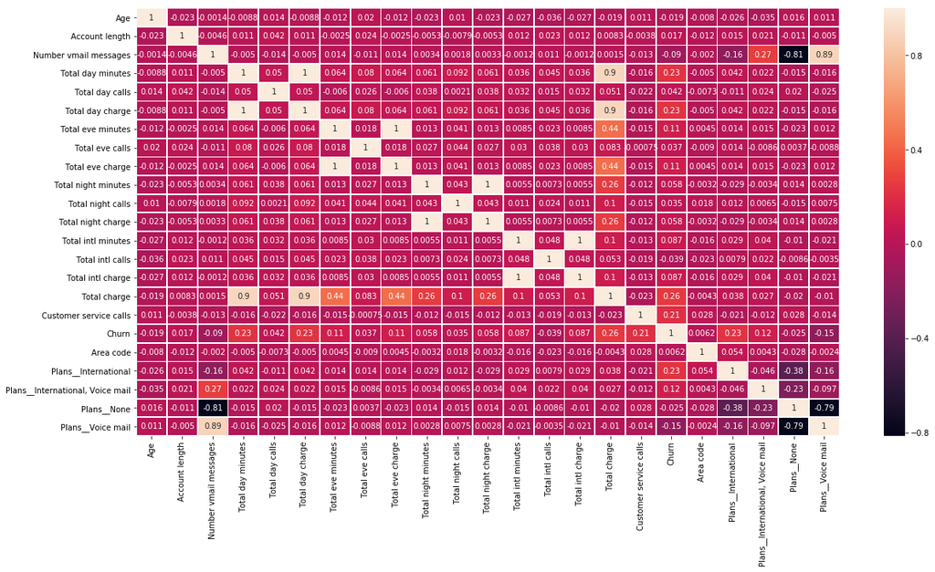

```python
corr_mat = df.drop(['ID', 'is_male'], axis=1).corr()
plt.figure(figsize=(20, 10))
sns.heatmap(corr_mat, annot=True, linewidths=.7)
plt.show()
```

Анализируя данную таблицу, можно сказать о том, что характеристики 'Total charge', 'Total night charge', 'Total eve minutes', 'Total intl minutes' - линейно зависимы, можем их отбросить в сторону

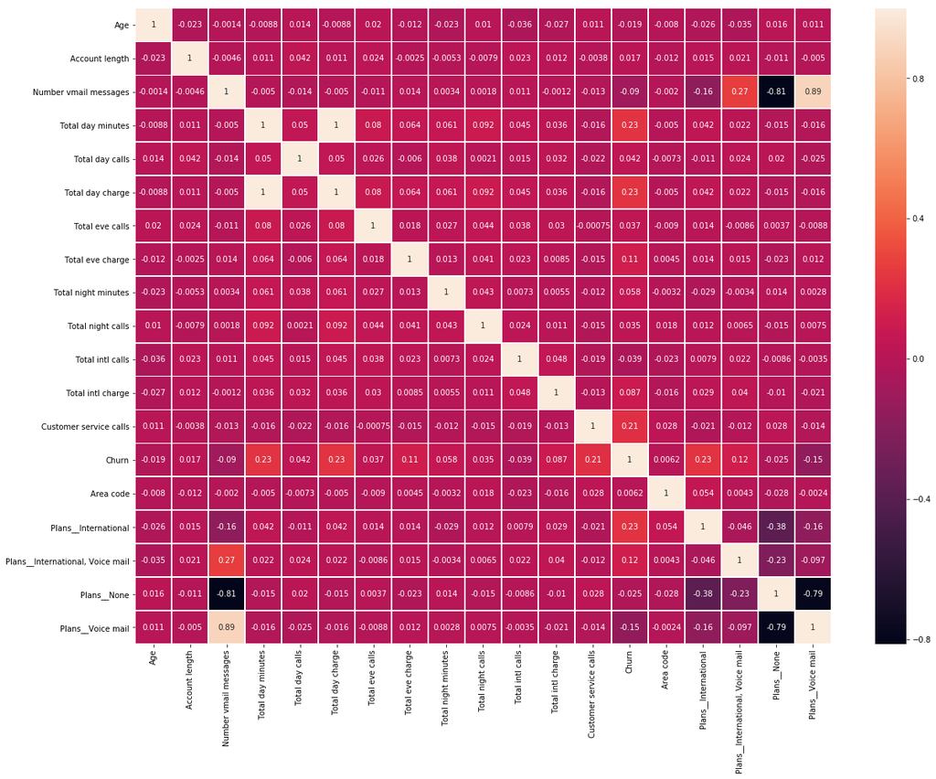

```python
plt.figure(figsize=(20, 15))
corr_mat = df.drop(['ID', 'is_male', 'Total charge', 'Total night charge', 'Total eve minutes', 'Total intl minutes'], axis=1).corr()
sns.heatmap(corr_mat, annot=True, linewidths=.7)
plt.show()
```

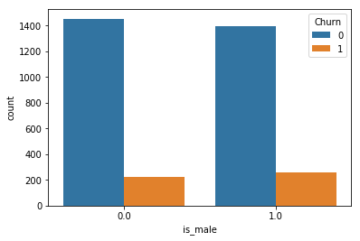

```python
sns.countplot(x='is_male',
              hue='Churn',
              data=df)
```

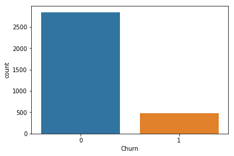

```python
sns.countplot(x='Churn', data=df)
```

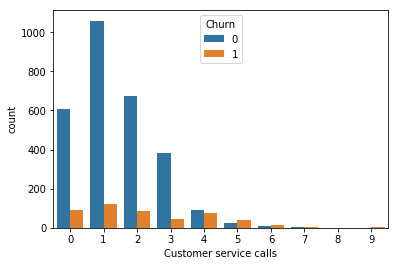

```python
sns.countplot(x='Customer service calls', hue='Churn', data=df);
```

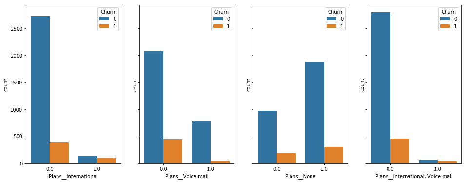

```python
_, axes = plt.subplots(1, 4, sharey=True, figsize=(16,6))
sns.countplot(x='Plans__International', hue='Churn', data=df, ax=axes[0]);
sns.countplot(x='Plans__Voice mail', hue='Churn', data=df, ax=axes[1]);
sns.countplot(x='Plans__None', hue='Churn', data=df, ax=axes[2]);
sns.countplot(x='Plans__International, Voice mail', hue='Churn', data=df, ax=axes[3]);
```

### Задание 10

Рассмотрим основанную на правилах модель для предсказания оттока клиентов:

- Если у пользователя подключен роуминг (International plan) & клиент звонил в тех. поддержку более 3-х раз => клиент уйдет (Churn = True)
- Иначе => клиент останется (Churn = False)

Оцените качество данной модели на 5-fold валидации из 5 повторений. Для оценки качества рассмотрите различные метрики: F1-score, precision, recall, accuracy, balanced accuracy. Дайте комментарий к оценке.

```python
# your code here
def ottock(data):
    temp = [None]*data.shape[0]
    for i in range(data.shape[0]):
        if (data['Plans__International'][i] == 1.0) or (data['Plans__International, Voice mail'][i] == 1.0):
            if data['Customer service calls'][i] > 3:
                temp[i] = 1
            else:
                temp[i] = 0
        else:
            temp[i] = 0
    return temp
```

```python
ot = ottock(df)
```

```python
from sklearn import metrics
print(metrics.classification_report(df['Churn'], ot))
print("Accuracy:",
round(metrics.accuracy_score(df['Churn'], ot), 5),
'\nBalanced accuracy:',
round(metrics.balanced_accuracy_score(df['Churn'],ot), 5))
```

```
              precision    recall  f1-score   support

           0       0.86      1.00      0.92      2850
           1       0.68      0.04      0.07       483

   micro avg       0.86      0.86      0.86      3333
   macro avg       0.77      0.52      0.50      3333
weighted avg       0.83      0.86      0.80      3333

Accuracy: 0.85809
Balanced accuracy: 0.51809
```

## Часть 2. Методы машинного обучения

Продолжаем работать с данными по оттоку клиентов.  
Сформулируем задачу машинного обучения: необходимо построить модель, определяющую, останется клиент или уйдет.

Для решения заданий, представленных ниже, необходимо использовать данные, полученные после выполнения всех преобразований в первой части.

### Задание 1

- Постройте дерево решений глубины 5 (остальные параметры по умолчанию), оцените качество на 5-fold валидации.
- Для одного из деревьев (т.е. обученного на одной из итераций кросс-валидации) выведите само дерево - постройте график или выведите в текстовом виде. По структуре дерева сформулируйте правила, по которым принимается решение.
- Сравните между собой деревья решений, полученных на различных итерациях 5-fold валидации. Сделайте вывод, насколько сильно они похожи или различаются между собой.

```python
# your code here
from sklearn.tree import DecisionTreeClassifier
from sklearn.model_selection import StratifiedKFold
from sklearn.model_selection import cross_val_score
import graphviz
from sklearn.tree import export_graphviz
```

```python
from sklearn.model_selection import train_test_split

(trainData,
 testData,
 train_label,
 test_label) = train_test_split(df.drop(['ID', 'Churn'], axis=1),
                                df['Churn'],
                                test_size=0.3,
                                random_state=236584)


print('Size of train set:', trainData.shape)
print('Size of test set:', testData.shape)
```

```
Size of train set: (2333, 23)
Size of test set: (1000, 23)
```

```python
print('Class distribution on train:',
      train_label.value_counts(normalize=True),
      '\nClass distribution on test:',
      test_label.value_counts(normalize=True),
      sep='\n')
```

```
Class distribution on train:
0    0.855551
1    0.144449
Name: Churn, dtype: float64

Class distribution on test:
0    0.854
1    0.146
Name: Churn, dtype: float64
```

```python
dtree_model = DecisionTreeClassifier(max_depth=5)
dtree_model.fit(trainData, train_label)
```

```
DecisionTreeClassifier(class_weight=None, criterion='gini', max_depth=5,
            max_features=None, max_leaf_nodes=None,
            min_impurity_decrease=0.0, min_impurity_split=None,
            min_samples_leaf=1, min_samples_split=2,
            min_weight_fraction_leaf=0.0, presort=False, random_state=None,
            splitter='best')
```

```python
dot_data = export_graphviz(dtree_model,
                           out_file=None,
                           feature_names=trainData.columns,
                           class_names=['0', '1'],
                           filled=True,
                           rounded=True,
                           special_characters=True)

graph = graphviz.Source(dot_data)
graph.render("dtree")
```

```
'dtree.pdf'
```

Оценим качество на валидации:

```python
dt = DecisionTreeClassifier()

skf = StratifiedKFold(n_splits=5, shuffle=True)

scores_dtree = []

Data = df.drop(['ID', 'Churn'], axis=1)
label = df['Churn']

for i in range(5):
    scores_dtree.extend(cross_val_score(dt, Data, label, cv=skf, scoring='f1_micro'))

scores_dtree = np.array(scores_dtree)

del Data, label

print('Mean score for DTree:', round(np.mean(scores_dtree), 5))
```

```
Mean score for DTree: 0.94731
```

### Задание 2

На кросс-валидации (5-fold из 5 повторений) оцените, как меняется качество модели Random Forest с ростом числа деревьев (при дефолтных значениях остальных параметров). Провизуализируйте результаты. Сколько деревьев достаточно в данном случае и почему?  
**NB:** В сравнение включите конфигурацию, аналогичную простому дереву решений.

```python
from sklearn.ensemble import RandomForestClassifier
from sklearn.model_selection import RepeatedStratifiedKFold
```

```python
Data = df.drop(['ID', 'Churn'], axis=1)
label = df['Churn']

(trainData,
 testData,
 train_label,
 test_label) = train_test_split(Data,
                                label,
                                test_size=0.3,
                                random_state=56428234)
print('Size of train set:', trainData.shape)
print('Size of test set:', testData.shape)
```

```
Size of train set: (2333, 23)
Size of test set: (1000, 23)
```

```python
print('Class distribution on train:',
      train_label.value_counts(normalize=True),
      '\nClass distribution on test:',
      test_label.value_counts(normalize=True),
      sep='\n')
```

```
Class distribution on train:
0    0.858123
1    0.141877
Name: Churn, dtype: float64

Class distribution on test:
0    0.848
1    0.152
Name: Churn, dtype: float64
```

Теперь обучим Random Forest с дефолтными параметрами

```python
rf_model = RandomForestClassifier()
rf_model.fit(trainData, train_label)
```

```
RandomForestClassifier(bootstrap=True, class_weight=None, criterion='gini',
            max_depth=None, max_features='auto', max_leaf_nodes=None,
            min_impurity_decrease=0.0, min_impurity_split=None,
            min_samples_leaf=1, min_samples_split=2,
            min_weight_fraction_leaf=0.0, n_estimators=10, n_jobs=None,
            oob_score=False, random_state=None, verbose=0,
            warm_start=False)
```

```python
preds = rf_model.predict(testData)
```

```python
scores = {1: [],
          2: [],
          5: [],
          10: [],
          50: [],
          100: []}

rskf = RepeatedStratifiedKFold(n_splits=5, n_repeats=5)

for x in scores:
    if x == 1:
        bootstrap = False
    else:
        bootstrap = True

    rf_model = RandomForestClassifier(n_estimators=x, bootstrap=bootstrap)
    scores[x] = cross_val_score(rf_model, Data, label, cv=rskf, scoring='f1_micro')

scores = pd.DataFrame(scores)
scores.columns = [str(x) + ' estimators' for x in scores.columns]
```

```python
scores.describe()
```

|  | 1 estimators | 2 estimators | 5 estimators | 10 estimators | 50 estimators | 100 estimators |
| --- | --- | --- | --- | --- | --- | --- |
| count | 25.000000 | 25.000000 | 25.000000 | 25.000000 | 25.000000 | 25.000000 |
| mean | 0.920553 | 0.929851 | 0.961836 | 0.965077 | 0.973056 | 0.974198 |
| std | 0.014701 | 0.013348 | 0.006527 | 0.007174 | 0.004800 | 0.004743 |
| min | 0.893553 | 0.905547 | 0.949025 | 0.950525 | 0.960961 | 0.965517 |
| 25% | 0.909910 | 0.922039 | 0.959459 | 0.959520 | 0.970015 | 0.971514 |
| 50% | 0.917417 | 0.931034 | 0.962462 | 0.965517 | 0.973013 | 0.974513 |
| 75% | 0.930931 | 0.937031 | 0.965517 | 0.971471 | 0.976012 | 0.977511 |
| max | 0.951952 | 0.955022 | 0.976012 | 0.978979 | 0.982009 | 0.983483 |

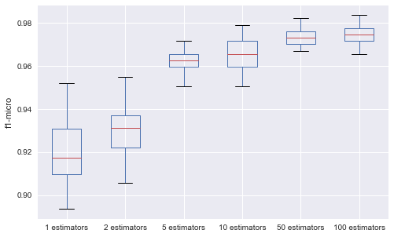

```python
from matplotlib import style
style.use('seaborn')
scores.boxplot(figsize=(8,5))
plt.ylabel('f1-micro')
plt.show()
```

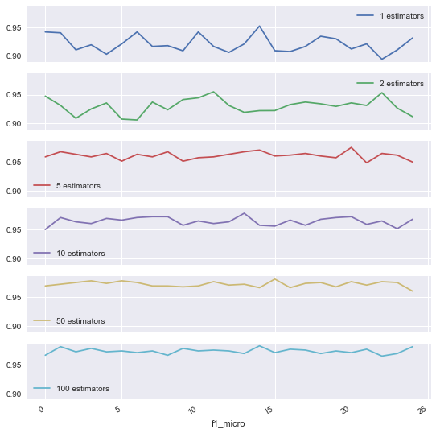

```python
scores.plot(subplots=True, sharey=True, figsize=(9, 10))
plt.xlabel('iteration')
plt.xlabel('f1_micro')
plt.show()
```

Анализируя данные графики, можно сказать о том, что достаточно 50 деревьев

### Задание 3

- Настройте гиперпараметры модели Random Forest на 5-fold валдиации из 5 повторений. В качестве метрики используйте F1-score. Замерьте время, затраченное на вычисления.
- Разделите данные на обучающую и тестовую выборки в пропорциях 70:30. Обучите Random Forest с настроенными параметрами на обучающей выборке. На тестовой выборке оцените качество (F1-score) всего ансамбля и каждого дерева отдельно. Постройте график распределения качества деревьев в ансамбле и сравните результаты с качеством всего леса. Дайте комментарий.
- Выведите важность признаков в Random Forest, сделайте выводы.

```python
params = [
    {
        'n_estimators': [50],
        'max_depth': range(5,11),
        'min_samples_split': range(2, 11),
        'min_samples_leaf': range(1, 11),
        'max_features': range(2, 19, 2)
    }
]
```

```python
from sklearn.model_selection import GridSearchCV
```

```python
rf_model = RandomForestClassifier()

skf = RepeatedStratifiedKFold(n_splits=5, n_repeats=5)

clf = GridSearchCV(rf_model, params, cv=skf, scoring='f1_micro', n_jobs=5)
```

```python
%%time
clf.fit(Data, label)
```

[output not shown]

```python
clf.best_params_
```

[output not shown]

```python
from sklearn.model_selection import train_test_split
```

```python
(trainData,
 testData,
 train_label,
 test_label) = train_test_split(Data,
                                label,
                                test_size=0.3,
                                random_state=56428234)
```

```python
rf_model = RandomForestClassifier(n_estimators=50,
                                  max_depth=70,
                                  min_samples_leaf=3,
                                  min_samples_split=2,
                                  max_features=5,
                                  bootstrap=False)

rf_model.fit(trainData, train_label)

preds = rf_model.predict(testData)

print("f1-score of forest: ", metrics.f1_score(test_label, preds))
```

```
f1-score of forest:  0.888086642599278
```

Посчитаем качество каждого дерева решений в лесу

```python
quality = pd.Series(
    [
        metrics.f1_score(test_label,
                         x.predict(testData)) for x in rf_model.estimators_
    ]
)
quality.describe()
```

```
count    50.000000
mean     0.747360
std      0.053853
min      0.639456
25%      0.715896
50%      0.761204
75%      0.776126
max      0.862319
dtype: float64
```

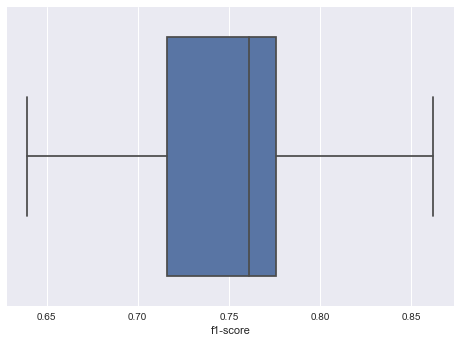

```python
sns.boxplot(quality)
plt.xlabel('f1-score')
plt.show()
```

Посмотрим на важность признаков

```python
pd.Series(rf_model.feature_importances_,
          index=Data.columns).sort_values(ascending=False)
```

```
Total charge                        0.239864
Customer service calls              0.145315
Total day minutes                   0.083915
Total day charge                    0.071709
Plans__Voice mail                   0.049414
Plans__International                0.049086
Total intl calls                    0.039419
Number vmail messages               0.039323
Total intl charge                   0.034034
Total eve minutes                   0.033048
Total intl minutes                  0.032831
Plans__None                         0.030991
Total eve charge                    0.030160
Plans__International, Voice mail    0.027121
Total night minutes                 0.015722
Total night charge                  0.014696
Total day calls                     0.014288
Total night calls                   0.012909
Total eve calls                     0.012594
Account length                      0.010524
Age                                 0.008329
is_male                             0.002354
Area code                           0.002354
dtype: float64
```

### Задание 4

- Используйте логистическую регрессию для решения задачи, оцените качество (roc auc) на 5-fold валидации из 5 повторений.
- Аналогично (на такой же валидации с такой же метрикой) оцените качество Random Forest с подобранными в предыдущем задании параметрами. Сравните с качеством логистическом регрессии.
- Разделите данные на обучающую и тестовую выборки в пропорциях 70:30. На обучающей выборке обучите логистическую регрессию и Random Forest с настроенными параметрами. Для обеих моделей оцените качество на тестовой выборке - постройте ROC-кривую, вычислите roc auc.

```python
from sklearn.linear_model import LogisticRegression
```

```python
rskf = RepeatedStratifiedKFold(n_splits=5, n_repeats=5)
log_res = LogisticRegression()

log_scores = pd.Series(cross_val_score(log_res, Data, label, cv=rskf, scoring='roc_auc'))
print(log_scores.mean())
```

```
0.8120520362331947
```

```python
rskf = RepeatedStratifiedKFold(n_splits=5, n_repeats=5)
rf_model = RandomForestClassifier(n_estimators=50,
                                  max_depth=70,
                                  min_samples_leaf=3,
                                  min_samples_split=2,
                                  max_features=5,
                                  bootstrap=False)
rf_scores = pd.Series(cross_val_score(rf_model, Data, label, cv=rskf, scoring='roc_auc'))

print(pd.Series(rf_scores).mean())
```

```
0.9149836129197564
```

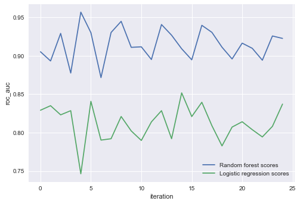

```python
pd.Series(rf_scores).plot(label='Random forest scores')
pd.Series(log_scores).plot(label='Logistic regression scores')

plt.ylabel('roc_auc')
plt.xlabel('iteration')

plt.legend()
plt.show()
```

```python
(trainData,
 testData,
 train_label,
 test_label) = train_test_split(Data,
                                label,
                                test_size=0.3,
                                random_state=56428234)
```

```python
rf_model.fit(trainData, train_label)
log_res.fit(trainData, train_label)
```

```
LogisticRegression(C=1.0, class_weight=None, dual=False, fit_intercept=True,
          intercept_scaling=1, max_iter=100, multi_class='warn',
          n_jobs=None, penalty='l2', random_state=None, solver='warn',
          tol=0.0001, verbose=0, warm_start=False)
```

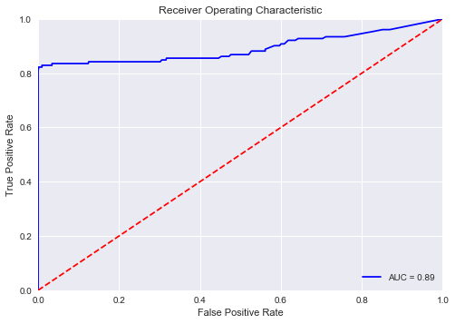

```python
# calculate the fpr and tpr for all thresholds of the classification
fpr, tpr, threshold = metrics.roc_curve(test_label, rf_model.predict_proba(testData)[:,1])
roc_auc = metrics.auc(fpr, tpr)


# plot auc
plt.plot(fpr, tpr, 'b', label = 'AUC = %0.2f' % roc_auc)
plt.plot([0, 1], [0, 1],'r--')

plt.xlim([0, 1])
plt.ylim([0, 1])

plt.ylabel('True Positive Rate')
plt.xlabel('False Positive Rate')

plt.title('Receiver Operating Characteristic')

plt.legend(loc = 'lower right')

plt.show()
```

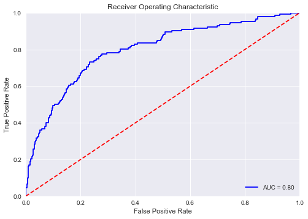

```python
# calculate the fpr and tpr for all thresholds of the classification
fpr, tpr, threshold = metrics.roc_curve(test_label, log_res.predict_proba(testData)[:, 1])
roc_auc = metrics.auc(fpr, tpr)


# plot auc
plt.plot(fpr, tpr, 'b', label = 'AUC = %0.2f' % roc_auc)
plt.plot([0, 1], [0, 1],'r--')

plt.xlim([0, 1])
plt.ylim([0, 1])

plt.ylabel('True Positive Rate')
plt.xlabel('False Positive Rate')

plt.title('Receiver Operating Characteristic')

plt.legend(loc = 'lower right')

plt.show()
```

### Задание 5

Настройте гиперпараметры модели SVM на 5-fold валидации из 5 повторений. В качестве метрики используйте F1-score. Замерьте время, затраченное на вычисления.  
Каково качество модели? Каков разброс значений метрики? Насколько сильно различие между лучшей и худшей конфигурациями параметров?

```python
from sklearn.svm import SVC
```

```python
rskf = RepeatedStratifiedKFold(n_splits=5, n_repeats=5)
cs = [0.001, 0.01, 0.1, 1, 10]
gammas = [0.001, 0.01, 0.1, 1]
param_grid = {'C': cs, 'gamma' : gammas}
clf = GridSearchCV(SVC(), param_grid, cv=rskf, scoring='f1_micro', n_jobs=5)
```

```python
%%time
clf.fit(Data, label)
print(clf.best_params_)
```

```
{'C': 1, 'gamma': 0.001}
Wall time: 5min 7s
```

```python
clf.best_score_
```

```
0.8598859885988599
```

### Задание 6

Для алгоритма AdaBoost с параметрами по умолчанию оцените на 5-fold валидации, как растет качество модели на обучающей и на тестовой выборках при добавлении каждого дерева. Провизуализируйте результаты.

```python
from sklearn.ensemble import AdaBoostClassifier
```

```python
f1_train = [] # will be list of lists of scores
acc_train = [] # will be list of lists of scores
f1_test = [] # will be list of lists of scores

skf = StratifiedKFold(n_splits=5, shuffle=True)

for train_index, test_index in skf.split(Data, label):

    # train data
    x_train = Data.iloc[train_index] # data
    y_train = label.iloc[train_index] # label

    # test data
    x_test = Data.iloc[test_index] # data
    y_test = label.iloc[test_index] # label

    # model
    ab_model = AdaBoostClassifier()
    ab_model.fit(x_train, y_train) # fitting

    # f1 on train on each stage
    scores = []
    for s in ab_model.staged_predict(x_train):
        scores.append(metrics.f1_score(y_train, s))
    f1_train.append(scores)
    del scores

    # f1 on test on each stage
    scores = []
    for s in ab_model.staged_predict(x_test):
        scores.append(metrics.f1_score(y_test, s))
    f1_test.append(scores)
    del scores

    # acc on train on each stage
    acc_train.append(list(ab_model.staged_score(x_train, y_train)))


# convert to DataFrame
f1_train = pd.DataFrame(f1_train).transpose()
acc_train = pd.DataFrame(acc_train).transpose()
f1_test = pd.DataFrame(f1_test).transpose()
```

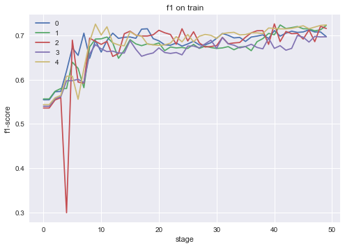

```python
f1_train.plot()

plt.xlabel('stage')
plt.ylabel('f1-score')
plt.title('f1 on train')

plt.show()
```

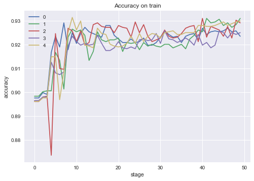

```python
acc_train.plot()

plt.xlabel('stage')
plt.ylabel('accuracy')
plt.title('Accuracy on train')

plt.show()
```

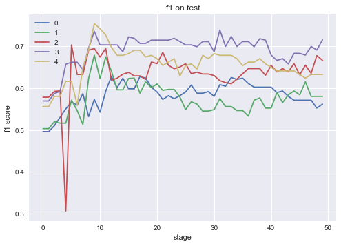

```python
f1_test.plot()

plt.xlabel('stage')
plt.ylabel('f1-score')
plt.title('f1 on test')

plt.show()
```

### Задание 7

- Настройте гиперпараметры AdaBoost на 5-fold валидации из 5 повторений, используя в качестве базовых классификаторов дерево решений и SVM. В качестве метрики используйте F1-score. Замерьте время, затраченное на вычисления.
- Выведите наилучшую конфигурацию параметров для каждого базового классификатора. Сравните качество.

```python
from sklearn.tree import DecisionTreeClassifier
```

```python
params = {
    'base_estimator__criterion' : ['gini', 'entropy'],
    'base_estimator__splitter' :   ['best', 'random'],
    'base_estimator__max_depth': range(1, 6),
    'n_estimators': range(10,101,10),
    'learning_rate': [0.5, 0.6, 0.7, 0.8, 0.9, 1]
}
```

```python
rskf = RepeatedStratifiedKFold(n_splits=5, n_repeats=2)
dtree_model = DecisionTreeClassifier()
ab_model = AdaBoostClassifier(base_estimator=dtree_model)
clf = GridSearchCV(ab_model, params, cv=rskf, scoring='f1_micro', n_jobs=2)
```

```python
%%time
clf.fit(data, label)
```

[output not shown]

```python
clf.best_score_
```

[output not shown]

```python
clf.best_params_
```

[output not shown]

## Часть 3. Соревнование по машинному обучению

В данном задании вам предлагается принять участие в соревновании на kaggle: [PUBG Finish Placement Prediction](https://www.kaggle.com/c/pubg-finish-placement-prediction).  
Задача соревнования заключается в том, чтобы предсказать итоговый результат игрока (место в турнирном зачете) в [популярной](https://meduza.io/feature/2017/12/22/u-etoy-igry-net-syuzheta-i-prokachki-ya-potratil-na-nee-100-chasov-zhizni-i-eto-tolko-nachalo) игре PlayerUnknownʼs Battlegrounds на основании результатов предыдущих игр.

Подробное описание задачи, данные и их описание, целевую метрику и правила вы можете найти на странице соревнования.

Для участия в соревновании, т.е. для того, чтобы скачать данные, сабмитить результаты и попасть в leaderboard, вам необходимо создать аккаунт на [kaggle](https://www.kaggle.com/).

Данное соревнование является `Kernels Only` - это означает, что вы должны сабмитить не файл с предсказаниями для тестовой выборки, а код, который будет выполняться (преобразовывать данные, обучать модель) и создавать файл с предсказаниями. Как это сделать сказано в [описании](https://www.kaggle.com/c/pubg-finish-placement-prediction#Kernels-FAQ), также есть хороший [тьюториал](https://www.kaggle.com/dansbecker/submitting-from-a-kernel).

После того, как вы выполните сабмит, в leaderboard вы сможете посмотреть качество вашей модели на тестовой выборке и место в общем зачете.  
Вы можете делать много (до 10 в день) сабмитов - в leaderbord всегда отображается самый лучший (остальные можно посмотреть в `My Submissions`).

### Задание

Необходимо построить и засабмитить модель, которая:

- Задача минимум – покажет на тестовой выборке качество выше baseline: 0.2
- Задача максимум - решит задачу как можно точнее

При решении можно и нужно выполнять различные преобразования признаков и применять различные модели машинного обучения.

В качестве результата необходимо:

- Сказать ваш логин на kaggle, чтобы мы могли найти вас в leaderboard
- Предоставить скрипт, выполняющий преобразования данных (из формата начальных данных в тот формат, который должна принимать на вход модель) и предсказания, а также сохраненную обученную модель.
- Предоставить скрипт, который вы сабмитили.
- Сделать краткое описание преобразования данных и итоговой модели. В описание можно также включить некоторые результаты анализа данных (если считаете их полезными и интересными) и собственную оценку модели на кросс-валидации.

По результатам будет составлен наш локальный leaderboard.